# Resumo modelos mistos

Douglas Silva Alves

2024-02-08

# Apresentação

O presente documento foi confeccionado para apresentar de forma resumida os resultados dos modelos mistos, tal como a análise do ajuste dos modelos aos dados, por meio da inspeção de seus resíduos

Neste documento estarão presentes somente os modelos que foram selecionados e se encontram descritos na dissertação. Para uma visualização mais ampla de todos os modelos construídos, refira-se à pasta “modelos mistos” do meu github

# Modelos mistos escolhidos

### Caso dê algum conflito para carregar o pacote “Matrix”, vamos reinstalá-lo através do comando abaixo:

```r
install.packages("Matrix", repos = "http://cran.us.r-project.org")
```

### Carregar bibliotecas necessárias

```r
library(statsr)
library(dplyr)
library(ggplot2)
library(readxl)
library(lubridate)
library(tidyr)
library(writexl)
library(kableExtra)
library(knitr)
library(lme4)
library(emmeans)

# Vamos carregar um pacote adicional, para os nossos modelos mistos exibirem os valores de p atrelados aos testes de hipótese
library(lmerTest)
```

Antes de visualizar os modelos escolhidos, vamos dar uma olhada em todos os modelos que foram construídos e seus respectivos índices de ajuste

### Para verificar todos os modelos que foram construídos, vamos carregar a tabela na qual eles estão descritos

```r
modelos_construidos <- read_excel("D:/Projeto_mestrado/Dissertacao/MastersDissertation/Modelos mistos/modelos_construidos.xlsx")

modelos_construidos
```

| Número | Desfecho | Método de remoção de outliers | Análise | Distribuição de probabilidade | Função de ligação | Preditores | Fator aleatório | Convergiu? | AIC/BIC | Modelo escolhido? |
| --- | --- | --- | --- | --- | --- | --- | --- | --- | --- | --- |
| 1 | Caminhada IPAQ | Nenhum | GLMM | Normal | Identidade | Tempo | Intercepto | Sim | 4728/4754 | 5 |
| 2 | Caminhada IPAQ | Nenhum | GLMM | Gama | Identidade | Tempo | Sujeitos | Não | - | NA |
| 3 | Caminhada IPAQ | Processamento dos dados seguindo as recomendações dos devs do IPAQ | GLMM | Normal | Identidade | Tempo | Sujeitos | Sim | 4244/4269 | NA |
| 4 | Caminhada IPAQ | Processamento dos dados seguindo as recomendações dos devs do IPAQ | GLMM | Gamma | Identidade | Tempo | Sujeitos | Não | - | NA |
| 5 | Caminhada IPAQ | Processamento dos dados seguindo as recomendações dos devs do IPAQ + z-score | GLMM | Normal | Identidade | Tempo | Sujeitos | Sim | 3861/3887 | NA |
| 6 | Caminhada IPAQ | Processamento dos dados seguindo as recomendações dos devs do IPAQ + z-score | GLMM | Gamma | Identidade | Tempo | Sujeitos | Não | 3640/3665 | NA |
| 7 | FLEEM leve | Nenhum | GLMM | Normal | Identidade | Tempo | Sujeitos | Sim | 4973/5000 | 7 |
| 8 | FLEEM leve | Nenhum | GLMM | Gama | Identidade | Tempo | Sujeitos | Sim | 4983/5009 | NA |
| 9 | FLEEM moderada | Nenhum | GLMM | Normal | Identidade | Tempo | Sujeitos | sim | 3808/3834 | 9 |
| 10 | FLEEM moderada | Nenhum | GLMM | Gama | Identidade | Tempo | Sujeitos | sim | 3768/3795 | NA |

[output cut: 14 more lines]

Agora vamos carregar os bancos de dados necessários para as análises

### Banco de dados sem remoção de outliers, para os modelos 7, 9 e 11, que foram construídos com os dados obtidos através do FLEEM SYSTEM

```r
dados1 <- read_excel("D:/Projeto_mestrado/Dissertacao/MastersDissertation/Dados/Quinto processamento/banco_dados_reestruturado.xlsx")

dados1
```

| ID | Idade | Sexo | Estatura | Massa | Trabalho | Escolaridade | Semana | Leve_FLEEM | Moderada_FLEEM_10 | Vigorosa_FLEEM_10 | Caminhada_IPAQ_10 | Moderada_IPAQ_10 | Vigorosa_IPAQ_10 |
| --- | --- | --- | --- | --- | --- | --- | --- | --- | --- | --- | --- | --- | --- |
| 1 | 23 | Masculino | 1.66 | 65.00 | Sim | Ensino superior completo | 1 | 2378 | 158 | 19 | 20 | 10 | 10 |
| 1 | 23 | Masculino | 1.66 | 65.00 | Sim | Ensino superior completo | 2 | 3158 | 234 | 144 | 40 | 10 | 10 |
| 1 | 23 | Masculino | 1.66 | 65.00 | Sim | Ensino superior completo | 3 | 3656 | 283 | 272 | 130 | 190 | 10 |
| 1 | 23 | Masculino | 1.66 | 65.00 | Sim | Ensino superior completo | 4 | 3015 | 302 | 283 | 170 | 110 | 10 |
| 1 | 23 | Masculino | 1.66 | 65.00 | Sim | Ensino superior completo | 5 | 2533 | 237 | 139 | 130 | 390 | 10 |
| 2 | 24 | Masculino | 1.78 | 84.00 | Sim | Ensino superior completo | 1 | 3082 | 313 | 397 | 145 | 1480 | 70 |
| 2 | 24 | Masculino | 1.78 | 84.00 | Sim | Ensino superior completo | 2 | 2750 | 277 | 319 | 70 | 670 | 10 |
| 2 | 24 | Masculino | 1.78 | 84.00 | Sim | Ensino superior completo | 3 | 3548 | 556 | 593 | 130 | 520 | 10 |
| 2 | 24 | Masculino | 1.78 | 84.00 | Sim | Ensino superior completo | 4 | 3370 | 445 | 498 | 100 | 430 | 10 |
| 2 | 24 | Masculino | 1.78 | 84.00 | Sim | Ensino superior completo | 5 | 3274 | 478 | 553 | 235 | 440 | 10 |

[output cut: 310 more lines]

### Podemos ver que a variável “semana” está definida como uma variável numérica. Portanto, vamos convertê-la em fator

```r
dados1$Semana <- as.factor(dados1$Semana)
```

Agora vamos conduzir as análises de fato

## Modelo 7 (FLEEM leve)

```r
modelo_FLEEM_leve1 <- lmer(Leve_FLEEM ~ Semana + (1 | ID), data = dados1, na.action = na.exclude)
AIC_modelo_FLEEM_leve1 <- AIC(modelo_FLEEM_leve1) #Extrai o AIC do modelo
AIC_modelo_FLEEM_leve1
```

```
## [1] 4973.792
```

```r
BIC(modelo_FLEEM_leve1) # Extrai o BIC do modelo
```

```
## [1] 5000.171
```

```r
# Vamos calcular o ICC, para ver o quanto os sujeitos explicam a variância do modelo

# Vamos primeiro extrair as variâncias atribuídas aos sujeitos, e a residual
var_ID_fleem_leve <- VarCorr(modelo_FLEEM_leve1)$ID
var_residual_fleem_leve <- sigma(modelo_FLEEM_leve1)^2

# Agora vamos calcular o ICC propriamente dito
ICC_modelo_leve_fleem <- var_ID_fleem_leve/(var_ID_fleem_leve+var_residual_fleem_leve)
ICC_modelo_leve_fleem[1]
```

```
## [1] 0.7521634
```

```r
# Vamos verificar um resumo do nosso modelo, com a função summary()
summary(modelo_FLEEM_leve1)
```

```
## Linear mixed model fit by REML. t-tests use Satterthwaite's method [
## lmerModLmerTest]
## Formula: Leve_FLEEM ~ Semana + (1 | ID)
##    Data: dados1
##
## REML criterion at convergence: 4959.8
##
## Scaled residuals:
##     Min      1Q  Median      3Q     Max
## -3.1178 -0.5494  0.0833  0.4986  3.8832
##
## Random effects:
##  Groups   Name        Variance Std.Dev.
##  ID       (Intercept) 656697   810.4
##  Residual             216380   465.2
## Number of obs: 320, groups:  ID, 64
##
## Fixed effects:
##             Estimate Std. Error       df t value Pr(>|t|)
## (Intercept) 2814.719    116.798   96.537  24.099   <2e-16 ***
## Semana2      -10.578     82.231  252.000  -0.129   0.8977
## Semana3      -10.563     82.231  252.000  -0.128   0.8979
## Semana4        8.766     82.231  252.000   0.107   0.9152
## Semana5     -150.297     82.231  252.000  -1.828   0.0688 .
## ---
## Signif. codes:  0 '***' 0.001 '**' 0.01 '*' 0.05 '.' 0.1 ' ' 1
##
## Correlation of Fixed Effects:
##         (Intr) Seman2 Seman3 Seman4
## Semana2 -0.352
## Semana3 -0.352  0.500
## Semana4 -0.352  0.500  0.500
## Semana5 -0.352  0.500  0.500  0.500
```

```r
# Esse pacote não exibe o efeito principal do nosso modelo, portanto, teremos que extrair isso usando a função anova()
anova(modelo_FLEEM_leve1)
```

|  | Sum Sq | Mean Sq | NumDF | DenDF | F value | Pr(>F) |
| --- | --- | --- | --- | --- | --- | --- |
| Semana | 1126209 | 281552.4 | 4 | 252 | 1.301191 | 0.2700891 |

```r
# As linhas acima não são suficientes para termos acesso à um teste posthoc, portanto, realizaremos isso de outra maneira

# Primeiro, vamos extrair as médias estimadas e realizar comparações
medias_emmeans_fleem_leve <- emmeans(modelo_FLEEM_leve1, ~ Semana)
```

```
## Cannot use mode = "kenward-roger" because *pbkrtest* package is not installed
```

```r
# Agora, vamos comparar todas as médias entre si
comparacoes_fleem_leve <- pairs(medias_emmeans_fleem_leve)

# Agora vamos exibir as comparações
print(comparacoes_fleem_leve)
```

```
##  contrast          estimate   SE  df t.ratio p.value
##  Semana1 - Semana2  10.5781 82.2 252   0.129  0.9999
##  Semana1 - Semana3  10.5625 82.2 252   0.128  0.9999
##  Semana1 - Semana4  -8.7656 82.2 252  -0.107  1.0000
##  Semana1 - Semana5 150.2969 82.2 252   1.828  0.3599
##  Semana2 - Semana3  -0.0156 82.2 252   0.000  1.0000
##  Semana2 - Semana4 -19.3438 82.2 252  -0.235  0.9993
##  Semana2 - Semana5 139.7188 82.2 252   1.699  0.4363
##  Semana3 - Semana4 -19.3281 82.2 252  -0.235  0.9993
##  Semana3 - Semana5 139.7344 82.2 252   1.699  0.4362
##  Semana4 - Semana5 159.0625 82.2 252   1.934  0.3019
##
## Degrees-of-freedom method: satterthwaite
## P value adjustment: tukey method for comparing a family of 5 estimates
```

Agora, vamos verificar o ajuste deste modelo quando comparado à um modelo equivalente, porém com uma distribuição de probabilidade Gamma. Para isso, utilizaremos gráficos construídos em Python, portanto, precisaremos carregar um pacote para permitir que os scripts em Python sejam “executados” no R markdown

```r
library("reticulate")
```

### Análise do ajuste do modelo por meio da inspeção da distribuição dos resíduos

#### Immportar bibliotecas necessárias

```python
import seaborn as sns
import numpy as np
import pandas as pd
import matplotlib.pyplot as plt
from scipy import stats
import statsmodels.api as sm
from scipy.special import ndtri
import matplotlib.lines as mlines
import matplotlib.transforms as mtransforms
import scipy
from distfit import distfit
import pylab as py
from scipy.stats import gamma
import math
```

#### Importar banco de dados com os resíduos do modelo

```python
dados = pd.read_excel('D:/Projeto_mestrado/Dissertacao/MastersDissertation/Modelos mistos/dados_com_residuos.xlsx')


#### Vamos remover os dados faltantes
dados = dados.dropna()
```

Vamos criar objetos com os valores preditos e os resíduos dos modelos com distribuição normal e Gamma

#### Criar objetos com os valores preditos e os resíduos

```python
resid_leve_linear = list(dados['Residuo_leve_1'].values)
preditos_leve_linear = list(dados['Predito_leve_1'].values)

#### Modelo com distribuição Gamma
resid_leve_gamma = list(dados['Residuo_leve_2'].values)
preditos_leve_gamma = list(dados['Predito_leve_2'].values)
```

Agora vamos converter os dados em um dataframe e calcular percentis

```python
# Modelo com distribuição linear
leve_fleem_linear_resid = pd.DataFrame(resid_leve_linear)
leve_fleem_linear_predito = pd.DataFrame(preditos_leve_linear)


# Modelo com distribuição Gamma
leve_fleem_gamma_resid = pd.DataFrame(resid_leve_gamma)
leve_fleem_gamma_predito = pd.DataFrame(preditos_leve_gamma)
```

#### Calcular percentis

```python
# Modelo com distribuição linear
df_leve_linear_resid = leve_fleem_linear_resid.sort_values(by=[0], ascending=True).reset_index()
df_leve_linear_resid['count'] = df_leve_linear_resid.index + 1
n_rows = df_leve_linear_resid.shape[0]
df_leve_linear_resid['percentil_area'] = (df_leve_linear_resid['count'])/n_rows
df_leve_linear_resid['percentil_teorico'] = ndtri(df_leve_linear_resid['percentil_area'])
df_leve_linear_resid['percentil_atual'] = (df_leve_linear_resid[0] - df_leve_linear_resid[0].mean())/df_leve_linear_resid[0].std(ddof=0)

# Modelo com distribuição Gamma
df_leve_gamma_resid = leve_fleem_gamma_resid.sort_values(by=[0], ascending=True).reset_index()
df_leve_gamma_resid['count'] = df_leve_gamma_resid.index + 1
n_rows = df_leve_gamma_resid.shape[0]
df_leve_gamma_resid['percentil_area'] = (df_leve_linear_resid['count'])/n_rows
df_leve_gamma_resid['percentil_teorico'] = ndtri(df_leve_gamma_resid['percentil_area'])
df_leve_gamma_resid['percentil_atual'] = (df_leve_gamma_resid[0] - df_leve_gamma_resid[0].mean())/df_leve_gamma_resid[0].std(ddof=0)
```

Agora vamos construir subplots para compararmos os ajustes dos modelos com distribuição normal e Gamma

#### Construir subplot para os dados de intensidade leve do FLEEM

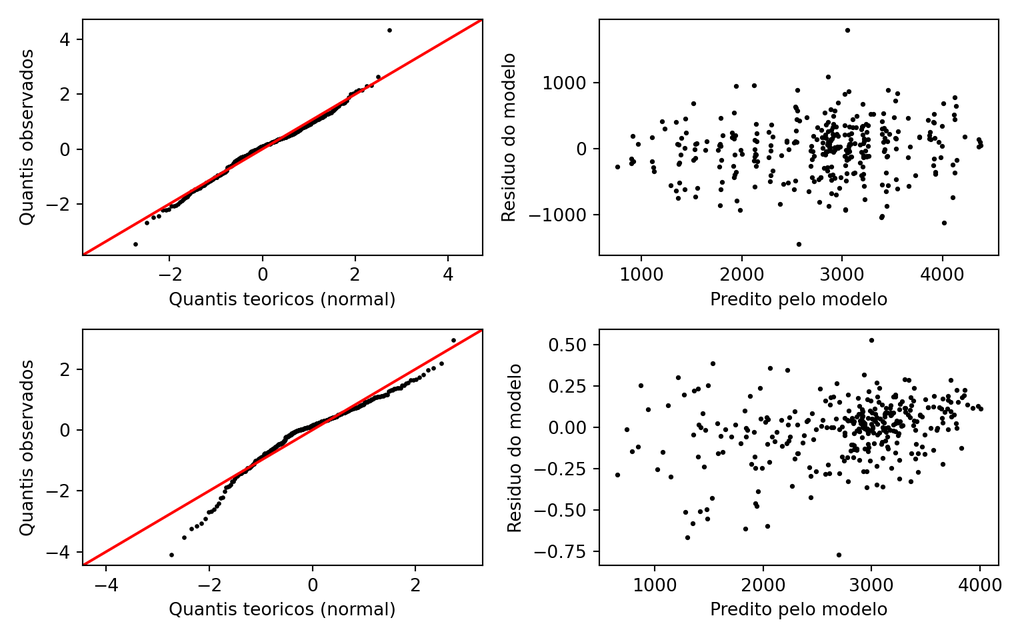

```python
fig, ((ax1,ax2), (ax3,ax4)) = plt.subplots(nrows = 2, ncols = 2, figsize=(8,5), sharey=False)


pp = sm.ProbPlot(df_leve_linear_resid.percentil_atual, dist=scipy.stats.distributions.norm, fit=True)
qq = pp.qqplot(marker='.', markerfacecolor='k', markeredgecolor='k', markersize=3, ax=ax1)
sm.qqline(qq.axes[0], line='45')
ax1.set_ylabel('Quantis observados')
ax1.set_xlabel('Quantis teoricos (normal)')
ax2.scatter(leve_fleem_linear_predito, leve_fleem_linear_resid, s=3, c='black')
ax2.set_ylabel('Residuo do modelo')
ax2.set_xlabel('Predito pelo modelo')

pp = sm.ProbPlot(df_leve_gamma_resid.percentil_atual, dist=scipy.stats.distributions.norm, fit=True)
qq = pp.qqplot(marker='.', markerfacecolor='k', markeredgecolor='k', markersize=3, ax=ax3)
sm.qqline(qq.axes[2], line='45')
ax3.set_ylabel('Quantis observados')
ax3.set_xlabel('Quantis teoricos (normal)')
ax4.scatter(leve_fleem_gamma_predito, leve_fleem_gamma_resid, s=3, c='black')
ax4.set_ylabel('Residuo do modelo')
ax4.set_xlabel('Predito pelo modelo')


plt.rcParams['axes.labelsize']=12
plt.rcParams['axes.titlesize']=12


plt.tight_layout()
#plt.savefig('D:/Projeto_mestrado/Dissertacao/MastersDissertation/An?lise dos residuos dos modelos mistos/FLEEM/residuo_leve_fleem.png', bbox_inches='tight', dpi = 300)
plt.show()
```

A primeira linha apresenta um modelo com distribuição normal, enquanto a segunda linha exibe um modelo com distribuição Gamma. Com base nisso, podemos concluir que o modelo com distribuição normal (cujos resultados estão expressos acima) foi o que melhor se ajustou aos dados, e consequentemente, foi o escolhido para ser interpretado

## Modelo 9 (FLEEM moderada)

```r
modelo_FLEEM_moderada1 <- lmer(Moderada_FLEEM_10 ~ Semana + (1 | ID), data = dados1, na.action = na.exclude)
AIC_modelo_FLEEM_moderada1 <- AIC(modelo_FLEEM_moderada1) #Extrai o AIC do modelo
AIC_modelo_FLEEM_moderada1
```

```
## [1] 3808.131
```

```r
BIC(modelo_FLEEM_moderada1) # Extrai o BIC do modelo
```

```
## [1] 3834.509
```

```r
# Vamos calcular o ICC, para ver o quanto os sujeitos explicam a variância do modelo

# Vamos primeiro extrair as variâncias atribuídas aos sujeitos, e a residual
var_ID_fleem_moderada <- VarCorr(modelo_FLEEM_moderada1)$ID
var_residual_fleem_moderada <- sigma(modelo_FLEEM_moderada1)^2

# Agora vamos calcular o ICC propriamente dito
ICC_modelo_moderada_fleem <- var_ID_fleem_moderada/(var_ID_fleem_moderada+var_residual_fleem_moderada)
ICC_modelo_moderada_fleem[1]
```

```
## [1] 0.7171805
```

```r
# Vamos verificar um resumo do nosso modelo, com a função summary()
summary(modelo_FLEEM_moderada1)
```

```
## Linear mixed model fit by REML. t-tests use Satterthwaite's method [
## lmerModLmerTest]
## Formula: Moderada_FLEEM_10 ~ Semana + (1 | ID)
##    Data: dados1
##
## REML criterion at convergence: 3794.1
##
## Scaled residuals:
##     Min      1Q  Median      3Q     Max
## -2.7167 -0.5857 -0.0538  0.5162  3.7854
##
## Random effects:
##  Groups   Name        Variance Std.Dev.
##  ID       (Intercept) 14021    118.41
##  Residual              5529     74.36
## Number of obs: 320, groups:  ID, 64
##
## Fixed effects:
##             Estimate Std. Error      df t value Pr(>|t|)
## (Intercept)  291.281     17.478 103.029  16.666   <2e-16 ***
## Semana2      -11.109     13.145 252.000  -0.845    0.399
## Semana3       10.000     13.145 252.000   0.761    0.448
## Semana4      -12.266     13.145 252.000  -0.933    0.352
## Semana5       -9.484     13.145 252.000  -0.722    0.471
## ---
## Signif. codes:  0 '***' 0.001 '**' 0.01 '*' 0.05 '.' 0.1 ' ' 1
##
## Correlation of Fixed Effects:
##         (Intr) Seman2 Seman3 Seman4
## Semana2 -0.376
## Semana3 -0.376  0.500
## Semana4 -0.376  0.500  0.500
## Semana5 -0.376  0.500  0.500  0.500
```

```r
# Esse pacote não exibe o efeito principal do nosso modelo, portanto, teremos que extrair isso usando a função anova()
anova(modelo_FLEEM_moderada1)
```

|  | Sum Sq | Mean Sq | NumDF | DenDF | F value | Pr(>F) |
| --- | --- | --- | --- | --- | --- | --- |
| Semana | 22995.64 | 5748.911 | 4 | 252 | 1.039739 | 0.3872173 |

```r
# As linhas acima não são suficientes para termos acesso à um teste posthoc, portanto, realizaremos isso de outra maneira

# Primeiro, vamos extrair as médias estimadas e realizar comparações
medias_emmeans_fleem_moderada <- emmeans(modelo_FLEEM_moderada1, ~ Semana)
```

```
## Cannot use mode = "kenward-roger" because *pbkrtest* package is not installed
```

```r
# Agora, vamos comparar todas as médias entre si
comparacoes_fleem_moderada <- pairs(medias_emmeans_fleem_moderada)

# Agora vamos exibir as comparações
print(comparacoes_fleem_moderada)
```

```
##  contrast          estimate   SE  df t.ratio p.value
##  Semana1 - Semana2    11.11 13.1 252   0.845  0.9162
##  Semana1 - Semana3   -10.00 13.1 252  -0.761  0.9415
##  Semana1 - Semana4    12.27 13.1 252   0.933  0.8838
##  Semana1 - Semana5     9.48 13.1 252   0.722  0.9514
##  Semana2 - Semana3   -21.11 13.1 252  -1.606  0.4950
##  Semana2 - Semana4     1.16 13.1 252   0.088  1.0000
##  Semana2 - Semana5    -1.62 13.1 252  -0.124  0.9999
##  Semana3 - Semana4    22.27 13.1 252   1.694  0.4396
##  Semana3 - Semana5    19.48 13.1 252   1.482  0.5750
##  Semana4 - Semana5    -2.78 13.1 252  -0.212  0.9996
##
## Degrees-of-freedom method: satterthwaite
## P value adjustment: tukey method for comparing a family of 5 estimates
```

Agora, vamos verificar o ajuste deste modelo quando comparado à um modelo equivalente, porém com uma distribuição de probabilidade Gamma

Vamos criar objetos com os valores preditos e os resíduos dos modelos com distribuição normal e Gamma

```python
# Modelo com distribuição linear
resid_moderada_linear = list(dados['Residuo_fmod_1'].values)
preditos_moderada_linear = list(dados['Predito_fmod_1'].values)

# Modelo com distribuição Gamma
resid_moderada_gamma = list(dados['Residuo_fmod_2'].values)
preditos_moderada_gamma = list(dados['Predito_fmod_1'].values)
```

Agora vamos converter os dados em um dataframe e calcular percentis

```python
# Modelo com distribuição linear
moderada_fleem_linear_resid = pd.DataFrame(resid_moderada_linear)
moderada_fleem_linear_predito = pd.DataFrame(preditos_moderada_linear)

# Modelo com distribuição Gamma
moderada_fleem_gamma_resid = pd.DataFrame(resid_moderada_gamma)
moderada_fleem_gamma_predito = pd.DataFrame(preditos_moderada_gamma)
```

#### Calcular percentis

```python
# Modelo com distribuição linear
df_moderada_linear_resid = moderada_fleem_linear_resid.sort_values(by=[0], ascending=True).reset_index()
df_moderada_linear_resid['count'] = df_moderada_linear_resid.index + 1
n_rows = df_moderada_linear_resid.shape[0]
df_moderada_linear_resid['percentil_area'] = (df_moderada_linear_resid['count'])/n_rows
df_moderada_linear_resid['percentil_teorico'] = ndtri(df_moderada_linear_resid['percentil_area'])
df_moderada_linear_resid['percentil_atual'] = (df_moderada_linear_resid[0] - df_moderada_linear_resid[0].mean())/df_moderada_linear_resid[0].std(ddof=0)

# Modelo com distribuição Gamma
df_moderada_gamma_resid = moderada_fleem_gamma_resid.sort_values(by=[0], ascending=True).reset_index()
df_moderada_gamma_resid['count'] = df_moderada_gamma_resid.index + 1
n_rows = df_moderada_gamma_resid.shape[0]
df_moderada_gamma_resid['percentil_area'] = (df_moderada_linear_resid['count'])/n_rows
df_moderada_gamma_resid['percentil_teorico'] = ndtri(df_moderada_gamma_resid['percentil_area'])
df_moderada_gamma_resid['percentil_atual'] = (df_moderada_gamma_resid[0] - df_moderada_gamma_resid[0].mean())/df_moderada_gamma_resid[0].std(ddof=0)
```

Agora vamos construir subplots para compararmos os ajustes dos modelos com distribuição normal e Gamma

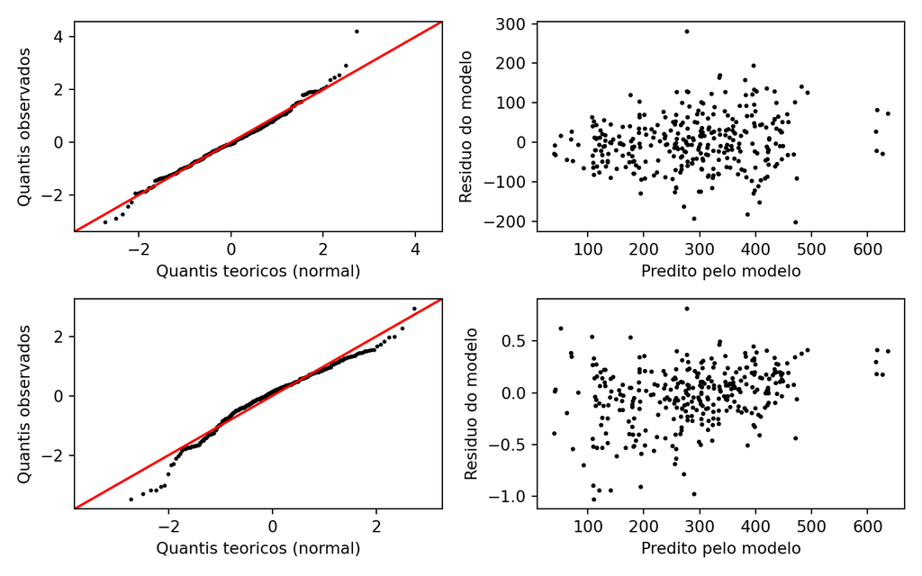

```python
fig, ((ax1,ax2), (ax3,ax4)) = plt.subplots(nrows = 2, ncols = 2, figsize=(8,5), sharey=False)


pp = sm.ProbPlot(df_moderada_linear_resid.percentil_atual, dist=scipy.stats.distributions.norm, fit=True)
qq = pp.qqplot(marker='.', markerfacecolor='k', markeredgecolor='k', markersize=3, ax=ax1)
sm.qqline(qq.axes[0], line='45')
ax1.set_ylabel('Quantis observados')
ax1.set_xlabel('Quantis teoricos (normal)')
ax2.scatter(moderada_fleem_linear_predito, moderada_fleem_linear_resid, s=3, c='black')
ax2.set_ylabel('Residuo do modelo')
ax2.set_xlabel('Predito pelo modelo')

pp = sm.ProbPlot(df_moderada_gamma_resid.percentil_atual, dist=scipy.stats.distributions.norm, fit=True)
qq = pp.qqplot(marker='.', markerfacecolor='k', markeredgecolor='k', markersize=3, ax=ax3)
sm.qqline(qq.axes[2], line='45')
ax3.set_ylabel('Quantis observados')
ax3.set_xlabel('Quantis teoricos (normal)')
ax4.scatter(moderada_fleem_gamma_predito, moderada_fleem_gamma_resid, s=3, c='black')
ax4.set_ylabel('Residuo do modelo')
ax4.set_xlabel('Predito pelo modelo')


plt.rcParams['axes.labelsize']=12
plt.rcParams['axes.titlesize']=12


plt.tight_layout()
#plt.savefig('D:/Projeto_mestrado/Dissertacao/MastersDissertation/An?lise dos residuos dos modelos mistos/FLEEM/residuo_moderada_fleem.png', bbox_inches='tight', dpi = 300)
plt.show()
```

A primeira linha apresenta um modelo com distribuição normal, enquanto a segunda linha exibe um modelo com distribuição Gamma. Com base nisso, podemos concluir que o modelo com distribuição normal (cujos resultados estão expressos acima) foi o que melhor se ajustou aos dados, e consequentemente, foi o escolhido para ser interpretado

## Modelo 11 (FLEEM vigorosa)

```r
modelo_FLEEM_vigorosa1 <- lmer(Vigorosa_FLEEM_10 ~ Semana + (1| ID), data = dados1, na.action = na.exclude)
AIC_modelo_FLEEM_vigorosa1 <- AIC(modelo_FLEEM_vigorosa1) # Extrai o AIC do modelo
AIC_modelo_FLEEM_vigorosa1
```

```
## [1] 3513.42
```

```r
BIC(modelo_FLEEM_vigorosa1) # Extrai o BIC do modelo
```

```
## [1] 3539.798
```

```r
# Vamos calcular o ICC, para ver o quanto os sujeitos explicam a variância do modelo

# Vamos primeiro extrair as variâncias atribuídas aos sujeitos, e a residual
var_ID_fleem_vigorosa <- VarCorr(modelo_FLEEM_vigorosa1)$ID
var_residual_fleem_vigorosa <- sigma(modelo_FLEEM_vigorosa1)^2

# Agora vamos calcular o ICC propriamente dito
ICC_modelo_vigorosa_fleem <- var_ID_fleem_vigorosa/(var_ID_fleem_vigorosa+var_residual_fleem_vigorosa)
ICC_modelo_vigorosa_fleem[1]
```

```
## [1] 0.7862895
```

```r
# Vamos verificar um resumo do nosso modelo, com a função summary()
summary(modelo_FLEEM_vigorosa1)
```

```
## Linear mixed model fit by REML. t-tests use Satterthwaite's method [
## lmerModLmerTest]
## Formula: Vigorosa_FLEEM_10 ~ Semana + (1 | ID)
##    Data: dados1
##
## REML criterion at convergence: 3499.4
##
## Scaled residuals:
##     Min      1Q  Median      3Q     Max
## -3.6811 -0.4574 -0.0639  0.3494  3.4581
##
## Random effects:
##  Groups   Name        Variance Std.Dev.
##  ID       (Intercept) 7443     86.27
##  Residual             2023     44.98
## Number of obs: 320, groups:  ID, 64
##
## Fixed effects:
##             Estimate Std. Error      df t value Pr(>|t|)
## (Intercept)  114.984     12.162  90.700   9.454 3.64e-15 ***
## Semana2       -9.313      7.951 252.000  -1.171    0.243
## Semana3       -8.906      7.951 252.000  -1.120    0.264
## Semana4      -12.672      7.951 252.000  -1.594    0.112
## Semana5      -12.438      7.951 252.000  -1.564    0.119
## ---
## Signif. codes:  0 '***' 0.001 '**' 0.01 '*' 0.05 '.' 0.1 ' ' 1
##
## Correlation of Fixed Effects:
##         (Intr) Seman2 Seman3 Seman4
## Semana2 -0.327
## Semana3 -0.327  0.500
## Semana4 -0.327  0.500  0.500
## Semana5 -0.327  0.500  0.500  0.500
```

```r
# Esse pacote não exibe o efeito principal do nosso modelo, portanto, teremos que extrair isso usando a função anova()
anova(modelo_FLEEM_vigorosa1)
```

|  | Sum Sq | Mean Sq | NumDF | DenDF | F value | Pr(>F) |
| --- | --- | --- | --- | --- | --- | --- |
| Semana | 6774.175 | 1693.544 | 4 | 252 | 0.8371227 | 0.5026828 |

```r
# As linhas acima não são suficientes para termos acesso à um teste posthoc, portanto, realizaremos isso de outra maneira

# Primeiro, vamos extrair as médias estimadas e realizar comparações
medias_emmeans_fleem_vigorosa <- emmeans(modelo_FLEEM_vigorosa1, ~ Semana)
```

```
## Cannot use mode = "kenward-roger" because *pbkrtest* package is not installed
```

```r
# Agora, vamos comparar todas as médias entre si
comparacoes_fleem_vigorosa <- pairs(medias_emmeans_fleem_vigorosa)

# Agora vamos exibir as comparações
print(comparacoes_fleem_vigorosa)
```

```
##  contrast          estimate   SE  df t.ratio p.value
##  Semana1 - Semana2    9.312 7.95 252   1.171  0.7678
##  Semana1 - Semana3    8.906 7.95 252   1.120  0.7958
##  Semana1 - Semana4   12.672 7.95 252   1.594  0.5028
##  Semana1 - Semana5   12.438 7.95 252   1.564  0.5218
##  Semana2 - Semana3   -0.406 7.95 252  -0.051  1.0000
##  Semana2 - Semana4    3.359 7.95 252   0.423  0.9933
##  Semana2 - Semana5    3.125 7.95 252   0.393  0.9949
##  Semana3 - Semana4    3.766 7.95 252   0.474  0.9897
##  Semana3 - Semana5    3.531 7.95 252   0.444  0.9919
##  Semana4 - Semana5   -0.234 7.95 252  -0.029  1.0000
##
## Degrees-of-freedom method: satterthwaite
## P value adjustment: tukey method for comparing a family of 5 estimates
```

Agora, vamos verificar o ajuste deste modelo quando comparado à um modelo equivalente, porém com uma distribuição de probabilidade Gamma

Vamos criar objetos com os valores preditos e os resíduos dos modelos com distribuição normal e Gamma

```python
# Modelo com distribuição linear
resid_vigorosa_linear = list(dados['Residuo_fvig_1'].values)
preditos_vigorosa_linear = list(dados['Predito_fvig_1'].values)

# Modelo com distribuição Gamma
resid_vigorosa_gamma = list(dados['Residuo_fvig_2'].values)
preditos_vigorosa_gamma = list(dados['Predito_fvig_2'].values)
```

Agora vamos converter os dados em um dataframe e calcular percentis

```python
# Modelo com distribuição linear
vigorosa_fleem_linear_resid = pd.DataFrame(resid_vigorosa_linear)
vigorosa_fleem_linear_predito = pd.DataFrame(preditos_vigorosa_linear)

# Modelo com distribuição Gamma
vigorosa_fleem_gamma_resid = pd.DataFrame(resid_vigorosa_gamma)
vigorosa_fleem_gamma_predito = pd.DataFrame(preditos_vigorosa_gamma)
```

#### Calcular percentis

```python
# Modelo com distribuição linear
df_vigorosa_linear_resid = vigorosa_fleem_linear_resid.sort_values(by=[0], ascending=True).reset_index()
df_vigorosa_linear_resid['count'] = df_vigorosa_linear_resid.index + 1
n_rows = df_vigorosa_linear_resid.shape[0]
df_vigorosa_linear_resid['percentil_area'] = (df_vigorosa_linear_resid['count'])/n_rows
df_vigorosa_linear_resid['percentil_teorico'] = ndtri(df_vigorosa_linear_resid['percentil_area'])
df_vigorosa_linear_resid['percentil_atual'] = (df_vigorosa_linear_resid[0] - df_vigorosa_linear_resid[0].mean())/df_vigorosa_linear_resid[0].std(ddof=0)

# Modelo com distribuição Gamma
df_vigorosa_gamma_resid = vigorosa_fleem_gamma_resid.sort_values(by=[0], ascending=True).reset_index()
df_vigorosa_gamma_resid['count'] = df_vigorosa_gamma_resid.index + 1
n_rows = df_vigorosa_gamma_resid.shape[0]
df_vigorosa_gamma_resid['percentil_area'] = (df_vigorosa_linear_resid['count'])/n_rows
df_vigorosa_gamma_resid['percentil_teorico'] = ndtri(df_vigorosa_gamma_resid['percentil_area'])
df_vigorosa_gamma_resid['percentil_atual'] = (df_vigorosa_gamma_resid[0] - df_vigorosa_gamma_resid[0].mean())/df_vigorosa_gamma_resid[0].std(ddof=0)
```

Agora vamos construir subplots para compararmos os ajustes dos modelos com distribuição normal e Gamma

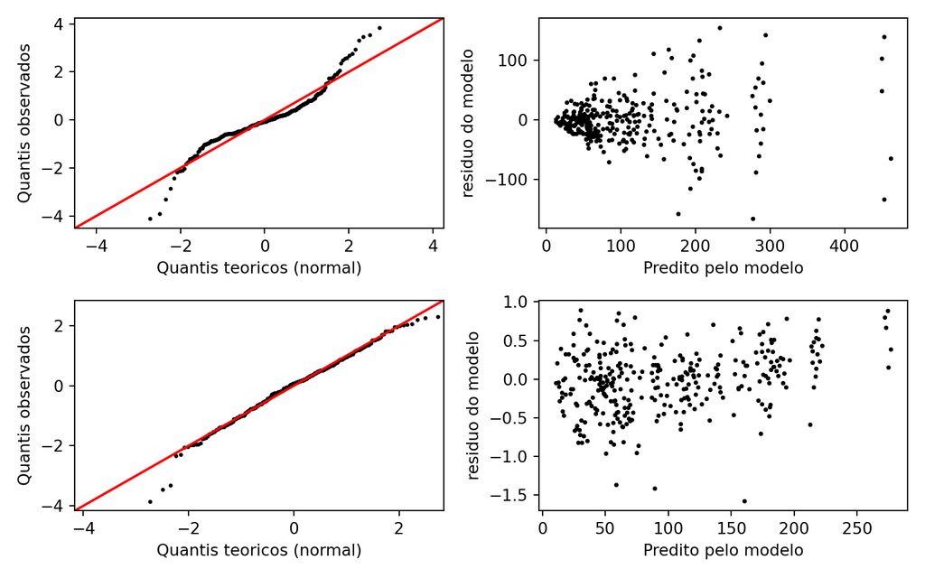

```python
fig, ((ax1,ax2), (ax3,ax4)) = plt.subplots(nrows = 2, ncols = 2, figsize=(8,5), sharey=False)


pp = sm.ProbPlot(df_vigorosa_linear_resid.percentil_atual, dist=scipy.stats.distributions.norm, fit=True)
qq = pp.qqplot(marker='.', markerfacecolor='k', markeredgecolor='k', markersize=3, ax=ax1)
sm.qqline(qq.axes[0], line='45')
ax1.set_ylabel('Quantis observados')
ax1.set_xlabel('Quantis teoricos (normal)')
ax2.scatter(vigorosa_fleem_linear_predito, vigorosa_fleem_linear_resid, s=3, c='black')
ax2.set_ylabel('residuo do modelo')
ax2.set_xlabel('Predito pelo modelo')

pp = sm.ProbPlot(df_vigorosa_gamma_resid.percentil_atual, dist=scipy.stats.distributions.norm, fit=True)
qq = pp.qqplot(marker='.', markerfacecolor='k', markeredgecolor='k', markersize=3, ax=ax3)
sm.qqline(qq.axes[2], line='45')
ax3.set_ylabel('Quantis observados')
ax3.set_xlabel('Quantis teoricos (normal)')
ax4.scatter(vigorosa_fleem_gamma_predito, vigorosa_fleem_gamma_resid, s=3, c='black')
ax4.set_ylabel('residuo do modelo')
ax4.set_xlabel('Predito pelo modelo')


plt.rcParams['axes.labelsize']=12
plt.rcParams['axes.titlesize']=12


plt.tight_layout()
#plt.savefig('D:/Projeto_mestrado/Dissertacao/MastersDissertation/An?lise dos residuos dos modelos mistos/FLEEM/residuo_vigorosa_fleem.png', bbox_inches='tight', dpi = 300)
plt.show()
```

Com base no gráfico acima, pode-se observar que, o resultado obtido para a última iteração do modelo com distribuição Gamma (que não convergiu) apresentou resíduos mais aderentes à uma distribuição normal. Entretanto, este modelo não convergiu, sendo assim escolhido o modelo com distribuição normal para ser analisado (cujos resultados encontram-se acima), adotando-se um critério de parsimonia

### Agora vamos trabalhar com o banco de dados para fazer as análises dos modelos 5, 18 e 23, que foram baseados em dados do IPAQ com a remoção de possíveis outliers

```r
dados2 <- read_excel("D:/Projeto_mestrado/Dissertacao/MastersDissertation/Dados/Sexto processamento/banco_dados_reestruturado_sem_outliers.xlsx")

dados2
```

| ID | Semana | Vigorosa_IPAQ_10 | Moderada_IPAQ_10 | Caminhada_IPAQ_10 |
| --- | --- | --- | --- | --- |
| 1 | 1 | 10 | 10 | 20 |
| 1 | 2 | 10 | 10 | 40 |
| 1 | 3 | 10 | 190 | 130 |
| 1 | 4 | 10 | 110 | 170 |
| 1 | 5 | 10 | 390 | 130 |
| 2 | 1 | 70 | 1480 | 145 |
| 2 | 2 | 10 | 670 | 70 |
| 2 | 3 | 10 | 520 | 130 |
| 2 | 4 | 10 | 430 | 100 |
| 2 | 5 | 10 | 440 | 235 |

[output cut: 278 more lines]

### Podemos ver que a variável “semana” está definida como uma variável numérica. Portanto, vamos convertê-la em fator

```r
dados2$Semana <- as.factor(dados2$Semana)
```

## Modelo 5 (Caminhada IPAQ)

```r
modelo_caminhada_ipaq <- lmer(Caminhada_IPAQ_10 ~ Semana + (1 | ID), data = dados2, na.action = na.exclude)
AIC_modelo_caminhada_ipaq <- AIC(modelo_caminhada_ipaq) # Extrai o AIC do modelo
AIC_modelo_caminhada_ipaq
```

```
## [1] 3861.968
```

```r
BIC(modelo_caminhada_ipaq) # Extrai o BIC do modelo
```

```
## [1] 3887.436
```

```r
# Vamos calcular o ICC, para ver o quanto os sujeitos explicam a variância do modelo

# Vamos primeiro extrair as variâncias atribuídas aos sujeitos, e a residual
var_ID_ipaq_caminhada <- VarCorr(modelo_caminhada_ipaq)$ID
var_residual_ipaq_caminhada <- sigma(modelo_caminhada_ipaq)^2

# Agora vamos calcular o ICC propriamente dito
ICC_modelo_ipaq_caminhada <- var_ID_ipaq_caminhada/(var_ID_ipaq_caminhada+var_residual_ipaq_caminhada)
ICC_modelo_ipaq_caminhada[1]
```

```
## [1] 0.735021
```

```r
# Vamos verificar um resumo do nosso modelo, com a função summary()
summary(modelo_caminhada_ipaq)
```

```
## Linear mixed model fit by REML. t-tests use Satterthwaite's method [
## lmerModLmerTest]
## Formula: Caminhada_IPAQ_10 ~ Semana + (1 | ID)
##    Data: dados2
##
## REML criterion at convergence: 3848
##
## Scaled residuals:
##     Min      1Q  Median      3Q     Max
## -3.2025 -0.4989 -0.1458  0.3467  3.8067
##
## Random effects:
##  Groups   Name        Variance Std.Dev.
##  ID       (Intercept) 96469    310.6
##  Residual             34778    186.5
## Number of obs: 281, groups:  ID, 63
##
## Fixed effects:
##             Estimate Std. Error      df t value Pr(>|t|)
## (Intercept)   433.46      47.35  100.69   9.155 6.68e-15 ***
## Semana2       -72.67      36.46  210.95  -1.993   0.0475 *
## Semana3       -87.91      36.16  209.92  -2.431   0.0159 *
## Semana4       -80.33      36.14  210.85  -2.223   0.0273 *
## Semana5      -161.39      36.08  210.24  -4.473 1.26e-05 ***
## ---
## Signif. codes:  0 '***' 0.001 '**' 0.01 '*' 0.05 '.' 0.1 ' ' 1
##
## Correlation of Fixed Effects:
##         (Intr) Seman2 Seman3 Seman4
## Semana2 -0.404
## Semana3 -0.403  0.522
## Semana4 -0.409  0.520  0.527
## Semana5 -0.407  0.522  0.528  0.529
```

```r
# Esse pacote não exibe o efeito principal do nosso modelo, portanto, teremos que extrair isso usando a função anova()
anova(modelo_caminhada_ipaq)
```

|  | Sum Sq | Mean Sq | NumDF | DenDF | F value | Pr(>F) |
| --- | --- | --- | --- | --- | --- | --- |
| Semana | 703744.3 | 175936.1 | 4 | 210.668 | 5.058875 | 0.0006520229 |

```r
# As linhas acima não são suficientes para termos acesso à um teste posthoc, portanto, realizaremos isso de outra maneira

# Primeiro, vamos extrair as médias estimadas e realizar comparações
medias_emmeans_ipaq_caminhada <- emmeans(modelo_caminhada_ipaq, ~ Semana)
```

```
## Cannot use mode = "kenward-roger" because *pbkrtest* package is not installed
```

```r
# Agora, vamos comparar todas as médias entre si
comparacoes_ipaq_caminhada <- pairs(medias_emmeans_ipaq_caminhada)

# Agora vamos exibir as comparações
print(comparacoes_ipaq_caminhada)
```

```
##  contrast          estimate   SE  df t.ratio p.value
##  Semana1 - Semana2    72.67 36.5 211   1.993  0.2729
##  Semana1 - Semana3    87.91 36.2 210   2.431  0.1111
##  Semana1 - Semana4    80.33 36.1 211   2.223  0.1753
##  Semana1 - Semana5   161.39 36.1 210   4.473  0.0001
##  Semana2 - Semana3    15.24 35.5 211   0.429  0.9929
##  Semana2 - Semana4     7.66 35.6 212   0.215  0.9995
##  Semana2 - Semana5    88.71 35.5 211   2.502  0.0941
##  Semana3 - Semana4    -7.58 35.2 211  -0.216  0.9995
##  Semana3 - Semana5    73.47 35.1 210   2.093  0.2270
##  Semana4 - Semana5    81.06 35.0 211   2.313  0.1449
##
## Degrees-of-freedom method: satterthwaite
## P value adjustment: tukey method for comparing a family of 5 estimates
```

Agora, vamos verificar o ajuste deste modelo quando comparado à um modelo equivalente, porém com uma distribuição de probabilidade Gamma

### Importar dados com resíduos do IPAQ

```python
dados_sem_outlier2 = pd.read_excel('D:/Projeto_mestrado/Dissertacao/MastersDissertation/Modelos mistos/dados__sem_outliers_z_score_com_residuos.xlsx')

dados_sem_outlier2
```

```
##      ID  Semana  ...  Predito_vig_SO_1  Residuo_vig_SO_1
## 0     1       1  ...         27.097969        -17.097969
## 1     1       2  ...          8.667021          1.332979
## 2     1       3  ...         37.039790        -27.039790
## 3     1       4  ...         11.972502         -1.972502
## 4     1       5  ...         10.134979         -0.134979
## ..   ..     ...  ...               ...               ...
## 283  79       5  ...         21.299038        -11.299038
## 284  80       2  ...         12.575673         -2.575673
## 285  80       3  ...         40.948443        -30.948443
## 286  80       4  ...         15.881154         -5.881154
## 287  80       5  ...         14.043632         -4.043632
##
## [288 rows x 13 columns]
```

Vamos criar objetos com os valores preditos e os resíduos dos modelos com distribuição normal e Gamma

```python
# Modelo com distribuicao linear
resid_caminhada_linear = list(dados_sem_outlier2['Residuo_cam__SO_1'].values)
preditos_caminhada_linear = list(dados_sem_outlier2['Predito_cam__SO_1'].values)

# Modelo com distribuicao gamma
# NAO CONVERGIU
```

Agora vamos salvar os dados em dataframes e calcular os percentis

```python
# Modelo com distribuicao linear
caminhada_ipaq_linear_resid = pd.DataFrame(resid_caminhada_linear).dropna()
caminhada_ipaq_linear_predito = pd.DataFrame(preditos_caminhada_linear).dropna()
```

### Calcular percentis

```python
# Modelo com distribuicao linear
df_caminhada_linear_resid = caminhada_ipaq_linear_resid.sort_values(by=[0], ascending=True).reset_index()
df_caminhada_linear_resid['count'] = df_caminhada_linear_resid.index + 1
n_rows = df_caminhada_linear_resid.shape[0]
df_caminhada_linear_resid['percentil_area'] = (df_caminhada_linear_resid['count'])/n_rows
df_caminhada_linear_resid['percentil_teorico'] = ndtri(df_caminhada_linear_resid['percentil_area'])
df_caminhada_linear_resid['percentil_atual'] = (df_caminhada_linear_resid[0] - df_caminhada_linear_resid[0].mean())/df_caminhada_linear_resid[0].std(ddof=0)
```

Agora vamos construir os nossos subplots para inspecionarmos a distribuição dos resíduos

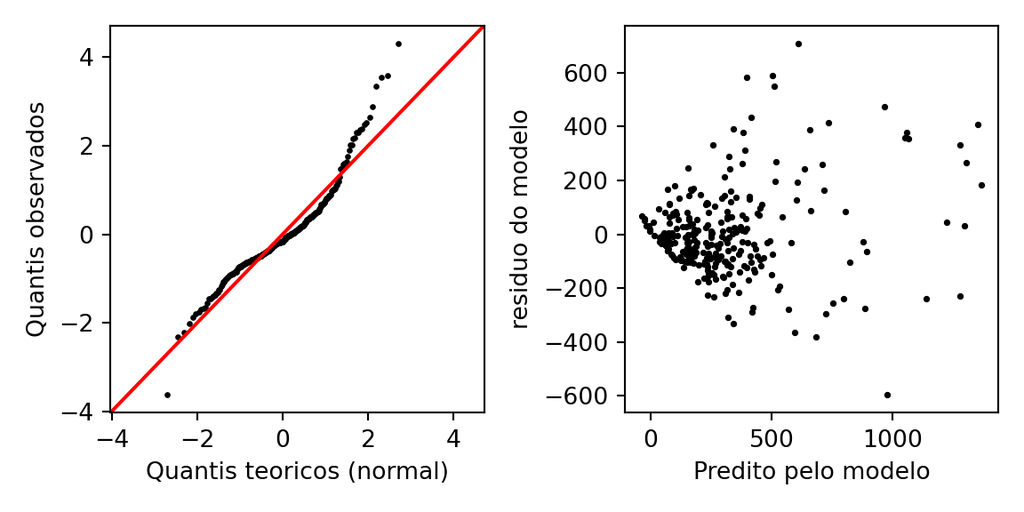

```python
fig, (ax1,ax2) = plt.subplots(nrows = 1, ncols = 2, figsize=(6,3), sharey=False)


pp = sm.ProbPlot(df_caminhada_linear_resid.percentil_atual, dist=scipy.stats.distributions.norm, fit=True)
qq = pp.qqplot(marker='.', markerfacecolor='k', markeredgecolor='k', markersize=3, ax=ax1)
sm.qqline(qq.axes[0], line='45')
ax1.set_ylabel('Quantis observados')
ax1.set_xlabel('Quantis teoricos (normal)')
ax2.scatter(caminhada_ipaq_linear_predito, caminhada_ipaq_linear_resid, s=3, c='black')
ax2.set_ylabel('residuo do modelo')
ax2.set_xlabel('Predito pelo modelo')


plt.rcParams['axes.labelsize']=12
plt.rcParams['axes.titlesize']=12


plt.tight_layout()
#plt.savefig('D:/Projeto_mestrado/Dissertacao/MastersDissertation/An?lise dos residuos dos modelos mistos/IPAQ/Outliers removidos z-score/residuo_modelo_caminhada_SO_z_ipaq.png', bbox_inches='tight', dpi = 300)
plt.show()
```

A partir do gráfico acima, podemos analisar a distribuição dos resíduos do modelo com distribuição normal. Não é expresso o ajuste do modelo com distribuição Gamma, pois ele não convergiu. Sendo assim, o modelo escolhido para ser interpretado foi o com distribuição normal

## Modelo 18 (Moderada IPAQ)

```r
modelo_moderada_ipaq <- glmer(Moderada_IPAQ_10 ~ Semana + (1 | ID), data = dados2, family = Gamma(link="identity"), na.action = na.exclude)
AIC_modelo_moderada_ipaq <- AIC(modelo_moderada_ipaq)
AIC_modelo_moderada_ipaq
```

```
## [1] 3685.76
```

```r
BIC(modelo_moderada_ipaq)
```

```
## [1] 3711.229
```

```r
# Vamos calcular o ICC, para ver o quanto os sujeitos explicam a variância do modelo

# Vamos primeiro extrair as variâncias atribuídas aos sujeitos, e a residual
var_ID_ipaq_moderada <- VarCorr(modelo_moderada_ipaq)$ID
var_residual_ipaq_moderada <- sigma(modelo_moderada_ipaq)^2

# Agora vamos calcular o ICC propriamente dito
ICC_modelo_ipaq_moderada <- var_ID_ipaq_moderada/(var_ID_ipaq_moderada+var_residual_ipaq_moderada)
ICC_modelo_ipaq_caminhada[1]
```

```
## [1] 0.735021
```

```r
# Vamos verificar um resumo do nosso modelo, com a função summary()
summary(modelo_moderada_ipaq)
```

```
## Generalized linear mixed model fit by maximum likelihood (Laplace
##   Approximation) [glmerMod]
##  Family: Gamma  ( identity )
## Formula: Moderada_IPAQ_10 ~ Semana + (1 | ID)
##    Data: dados2
##
##      AIC      BIC   logLik deviance df.resid
##   3685.8   3711.2  -1835.9   3671.8      274
##
## Scaled residuals:
##     Min      1Q  Median      3Q     Max
## -1.5529 -0.4440 -0.0492  0.4206  3.9021
##
## Random effects:
##  Groups   Name        Variance  Std.Dev.
##  ID       (Intercept) 31124.415 176.4211
##  Residual                 0.396   0.6293
## Number of obs: 281, groups:  ID, 62
##
## Fixed effects:
##              Estimate Std. Error t value Pr(>|z|)
## (Intercept) 394.35637   27.80873  14.181   <2e-16 ***
## Semana2       2.74860   10.32410   0.266    0.790
## Semana3      -3.63918    7.26098  -0.501    0.616
## Semana4       0.08429    7.97518   0.011    0.992
## Semana5       0.65101    8.04828   0.081    0.936
## ---
## Signif. codes:  0 '***' 0.001 '**' 0.01 '*' 0.05 '.' 0.1 ' ' 1
##
## Correlation of Fixed Effects:
##         (Intr) Seman2 Seman3 Seman4
## Semana2 -0.108
## Semana3 -0.106  0.503
## Semana4 -0.101  0.423  0.687
## Semana5 -0.104  0.452  0.697  0.589
```

```r
# Esse pacote não exibe o efeito principal do nosso modelo, portanto, teremos que extrair isso usando a função anova()
anova(modelo_moderada_ipaq)
```

|  | npar | Sum Sq | Mean Sq | F value |
| --- | --- | --- | --- | --- |
| Semana | 4 | 0.348715 | 0.08717875 | 0.2201591 |

```r
# As linhas acima não são suficientes para termos acesso à um teste posthoc, portanto, realizaremos isso de outra maneira
# Primeiro, vamos extrair as médias estimadas e realizar comparações
medias_emmeans_ipaq_moderada <- emmeans(modelo_moderada_ipaq, ~ Semana)

# Agora, vamos comparar todas as médias entre si
comparacoes_ipaq_moderada <- pairs(medias_emmeans_ipaq_moderada)

# Agora vamos exibir as comparações
print(comparacoes_ipaq_moderada)
```

```
##  contrast          estimate    SE  df z.ratio p.value
##  Semana1 - Semana2  -2.7486 10.32 Inf  -0.266  0.9989
##  Semana1 - Semana3   3.6392  7.26 Inf   0.501  0.9873
##  Semana1 - Semana4  -0.0843  7.98 Inf  -0.011  1.0000
##  Semana1 - Semana5  -0.6510  8.05 Inf  -0.081  1.0000
##  Semana2 - Semana3   6.3878  9.16 Inf   0.698  0.9571
##  Semana2 - Semana4   2.6643 10.02 Inf   0.266  0.9989
##  Semana2 - Semana5   2.0976  9.81 Inf   0.214  0.9995
##  Semana3 - Semana4  -3.7235  6.07 Inf  -0.614  0.9729
##  Semana3 - Semana5  -4.2902  6.00 Inf  -0.715  0.9532
##  Semana4 - Semana5  -0.5667  7.27 Inf  -0.078  1.0000
##
## P value adjustment: tukey method for comparing a family of 5 estimates
```

Agora, vamos verificar o ajuste deste modelo quando comparado à um modelo equivalente, porém com uma distribuição de probabilidade Gamma  
Vamos criar objetos com os valores preditos e os resíduos dos modelos com distribuição normal e Gamma

```python
# Modelo com distribuicao linear
resid_moderada_linear = list(dados_sem_outlier2['Residuo_mod_SO_1'].values)
preditos_moderada_linear = list(dados_sem_outlier2['Predito_mod__SO_1'].values)


# Modelo com distribuicao gamma
resid_moderada_gamma = list(dados_sem_outlier2['Residuo_mod_SO_2'].values)
preditos_moderada_gamma = list(dados_sem_outlier2['Predito_mod__SO_2'].values)
```

Agora vamos salvar os dados em dataframes e calcular os percentis

```python
# Modelo com distribuicao linear
moderada_ipaq_linear_resid = pd.DataFrame(resid_moderada_linear).dropna()
moderada_ipaq_linear_predito = pd.DataFrame(preditos_moderada_linear).dropna()


# Modelo com distribuicao Gamma
moderada_ipaq_gamma_resid = pd.DataFrame(resid_moderada_gamma).dropna()
moderada_ipaq_gamma_predito = pd.DataFrame(preditos_moderada_gamma).dropna()
```

### Calcular percentis

```python
# Modelo com distribuicao linear
df_moderada_linear_resid = moderada_ipaq_linear_resid.sort_values(by=[0], ascending=True).reset_index()
df_moderada_linear_resid['count'] = df_moderada_linear_resid.index + 1
n_rows = df_moderada_linear_resid.shape[0]
df_moderada_linear_resid['percentil_area'] = (df_moderada_linear_resid['count'])/n_rows
df_moderada_linear_resid['percentil_teorico'] = ndtri(df_moderada_linear_resid['percentil_area'])
df_moderada_linear_resid['percentil_atual'] = (df_moderada_linear_resid[0] - df_moderada_linear_resid[0].mean())/df_moderada_linear_resid[0].std(ddof=0)


# Modelo com distribuicao Gamma
df_moderada_gamma_resid = moderada_ipaq_gamma_resid.sort_values(by=[0], ascending=True).reset_index()
df_moderada_gamma_resid['count'] = df_moderada_gamma_resid.index + 1
n_rows = df_moderada_gamma_resid.shape[0]
df_moderada_gamma_resid['percentil_area'] = (df_moderada_gamma_resid['count'])/n_rows
df_moderada_gamma_resid['percentil_teorico'] = ndtri(df_moderada_gamma_resid['percentil_area'])
df_moderada_gamma_resid['percentil_atual'] = (df_moderada_gamma_resid[0] - df_moderada_gamma_resid[0].mean())/df_moderada_gamma_resid[0].std(ddof=0)
```

Agora vamos construir os nossos subplots para inspecionarmos a distribuição dos resíduos

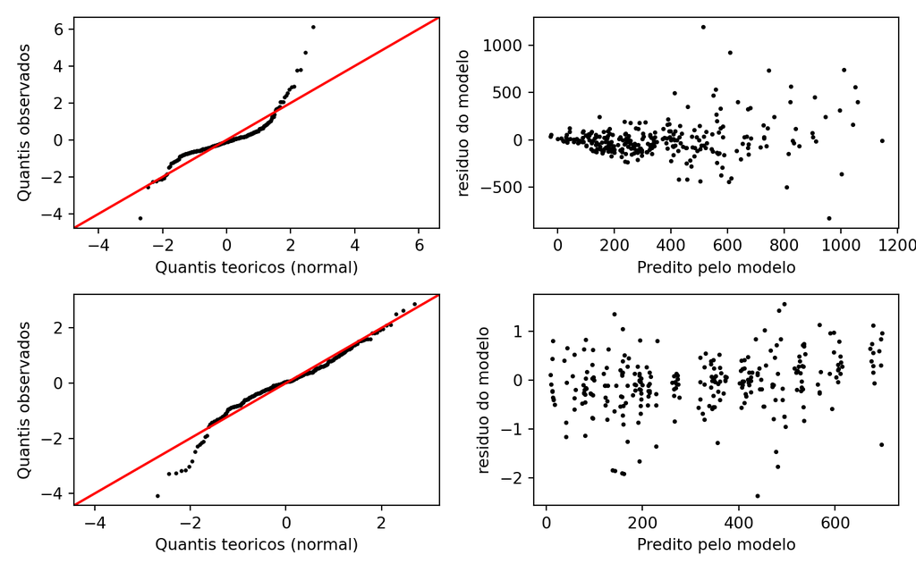

```python
fig, ((ax1,ax2), (ax3, ax4)) = plt.subplots(nrows = 2, ncols = 2, figsize=(8,5), sharey=False)


pp = sm.ProbPlot(df_moderada_linear_resid.percentil_atual, dist=scipy.stats.distributions.norm, fit=True)
qq = pp.qqplot(marker='.', markerfacecolor='k', markeredgecolor='k', markersize=3, ax=ax1)
sm.qqline(qq.axes[0], line='45')
ax1.set_ylabel('Quantis observados')
ax1.set_xlabel('Quantis teoricos (normal)')
ax2.scatter(moderada_ipaq_linear_predito, moderada_ipaq_linear_resid, s=3, c='black')
ax2.set_ylabel('residuo do modelo')
ax2.set_xlabel('Predito pelo modelo')


pp = sm.ProbPlot(df_moderada_gamma_resid.percentil_atual, dist=scipy.stats.distributions.norm, fit=True)
qq = pp.qqplot(marker='.', markerfacecolor='k', markeredgecolor='k', markersize=3, ax=ax3)
sm.qqline(qq.axes[2], line='45')
ax3.set_ylabel('Quantis observados')
ax3.set_xlabel('Quantis teoricos (normal)')
ax4.scatter(moderada_ipaq_gamma_predito, moderada_ipaq_gamma_resid, s=3, c='black')
ax4.set_ylabel('residuo do modelo')
ax4.set_xlabel('Predito pelo modelo')


plt.rcParams['axes.labelsize']=12
plt.rcParams['axes.titlesize']=12


plt.tight_layout()
#plt.savefig('D:/Projeto_mestrado/Dissertacao/MastersDissertation/An?lise dos residuos dos modelos mistos/IPAQ/Outliers removidos z-score/residuo_modelo_moderada_SO_z_ipaq.png', bbox_inches='tight', dpi = 300)
plt.show()
```

Com base no gráfico acima, podemos observar que o modelo com distribuição Gamma se adequou melhor aos dados, portanto, foi o escolhido para ser interpretado

## Modelo 23 (Vigorosa IPAQ)

```r
modelo_vigorosa_ipaq <- lmer(Vigorosa_IPAQ_10 ~ Semana + (1 | ID), data = dados2, na.action = na.exclude)
AIC_modelo_vigorosa_ipaq <- AIC(modelo_vigorosa_ipaq) #Extrai o AIC do modelo
AIC_modelo_vigorosa_ipaq
```

```
## [1] 3530.872
```

```r
BIC(modelo_vigorosa_ipaq)
```

```
## [1] 3556.512
```

```r
# Vamos calcular o ICC, para ver o quanto os sujeitos explicam a variância do modelo

# Vamos primeiro extrair as variâncias atribuídas aos sujeitos, e a residual
var_ID_ipaq_vigorosa <- VarCorr(modelo_vigorosa_ipaq)$ID
var_residual_ipaq_vigorosa <- sigma(modelo_vigorosa_ipaq)^2

# Agora vamos calcular o ICC propriamente dito
ICC_modelo_ipaq_vigorosa <- var_ID_ipaq_vigorosa/(var_ID_ipaq_vigorosa+var_residual_ipaq_vigorosa)
ICC_modelo_ipaq_vigorosa[1]
```

```
## [1] 0.7275958
```

```r
# Vamos verificar um resumo do nosso modelo, com a função summary()
summary(modelo_vigorosa_ipaq)
```

```
## Linear mixed model fit by REML. t-tests use Satterthwaite's method [
## lmerModLmerTest]
## Formula: Vigorosa_IPAQ_10 ~ Semana + (1 | ID)
##    Data: dados2
##
## REML criterion at convergence: 3516.9
##
## Scaled residuals:
##     Min      1Q  Median      3Q     Max
## -2.6274 -0.3862 -0.0663  0.2206  3.8391
##
## Random effects:
##  Groups   Name        Variance Std.Dev.
##  ID       (Intercept) 20733    144.0
##  Residual              7762     88.1
## Number of obs: 288, groups:  ID, 63
##
## Fixed effects:
##             Estimate Std. Error      df t value Pr(>|t|)
## (Intercept)  147.059     21.970 105.643   6.694 1.08e-09 ***
## Semana2      -18.431     16.856 220.851  -1.093    0.275
## Semana3        9.942     16.908 219.751   0.588    0.557
## Semana4      -15.125     16.865 219.948  -0.897    0.371
## Semana5      -16.963     16.957 220.124  -1.000    0.318
## ---
## Signif. codes:  0 '***' 0.001 '**' 0.01 '*' 0.05 '.' 0.1 ' ' 1
##
## Correlation of Fixed Effects:
##         (Intr) Seman2 Seman3 Seman4
## Semana2 -0.414
## Semana3 -0.406  0.527
## Semana4 -0.409  0.534  0.530
## Semana5 -0.408  0.530  0.524  0.528
```

```r
# Esse pacote não exibe o efeito principal do nosso modelo, portanto, teremos que extrair isso usando a função anova()
anova(modelo_vigorosa_ipaq)
```

|  | Sum Sq | Mean Sq | NumDF | DenDF | F value | Pr(>F) |
| --- | --- | --- | --- | --- | --- | --- |
| Semana | 35383.18 | 8845.796 | 4 | 220.0943 | 1.139624 | 0.3387291 |

```r
# As linhas acima não são suficientes para termos acesso à um teste posthoc, portanto, realizaremos isso de outra maneira

# Primeiro, vamos extrair as médias estimadas e realizar comparações
medias_emmeans_ipaq_vigorosa <- emmeans(modelo_vigorosa_ipaq, ~ Semana)
```

```
## Cannot use mode = "kenward-roger" because *pbkrtest* package is not installed
```

```r
# Agora, vamos comparar todas as médias entre si
comparacoes_ipaq_vigorosa <- pairs(medias_emmeans_ipaq_vigorosa)

# Agora vamos exibir as comparações
print(comparacoes_ipaq_vigorosa)
```

```
##  contrast          estimate   SE  df t.ratio p.value
##  Semana1 - Semana2    18.43 16.9 221   1.093  0.8098
##  Semana1 - Semana3    -9.94 16.9 220  -0.588  0.9768
##  Semana1 - Semana4    15.13 16.9 220   0.897  0.8978
##  Semana1 - Semana5    16.96 17.0 220   1.000  0.8550
##  Semana2 - Semana3   -28.37 16.4 221  -1.729  0.4185
##  Semana2 - Semana4    -3.31 16.3 220  -0.203  0.9996
##  Semana2 - Semana5    -1.47 16.4 220  -0.090  1.0000
##  Semana3 - Semana4    25.07 16.4 219   1.530  0.5439
##  Semana3 - Semana5    26.90 16.5 220   1.629  0.4804
##  Semana4 - Semana5     1.84 16.4 220   0.112  1.0000
##
## Degrees-of-freedom method: satterthwaite
## P value adjustment: tukey method for comparing a family of 5 estimates
```

```python
# Modelo com distribuicao linear
resid_vigorosa_linear = list(dados_sem_outlier2['Residuo_vig_SO_1'].values)
preditos_vigorosa_linear = list(dados_sem_outlier2['Predito_vig_SO_1'].values)


# Modelo com distribuicao gamma
# NAO CONVERGIU
```

Agora vamos salvar os dados em dataframes e calcular os percentis

```python
# Modelo com distribuicao linear
vigorosa_ipaq_linear_resid = pd.DataFrame(resid_vigorosa_linear).dropna()
vigorosa_ipaq_linear_predito = pd.DataFrame(preditos_vigorosa_linear).dropna()
```

### Calcular percentis

```python
# Modelo com distribuicao linear
df_vigorosa_linear_resid = vigorosa_ipaq_linear_resid.sort_values(by=[0], ascending=True).reset_index()
df_vigorosa_linear_resid['count'] = df_vigorosa_linear_resid.index + 1
n_rows = df_vigorosa_linear_resid.shape[0]
df_vigorosa_linear_resid['percentil_area'] = (df_vigorosa_linear_resid['count'])/n_rows
df_vigorosa_linear_resid['percentil_teorico'] = ndtri(df_vigorosa_linear_resid['percentil_area'])
df_vigorosa_linear_resid['percentil_atual'] = (df_vigorosa_linear_resid[0] - df_vigorosa_linear_resid[0].mean())/df_vigorosa_linear_resid[0].std(ddof=0)
```

Agora vamos construir os nossos subplots para inspecionarmos a distribuição dos resíduos

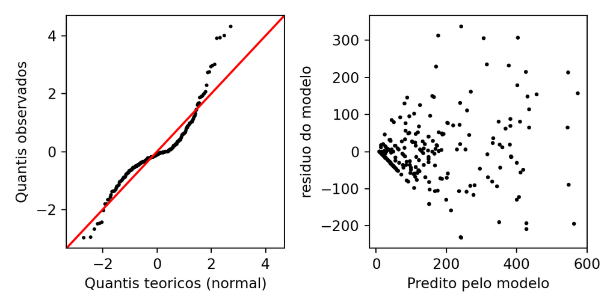

```python
fig, (ax1,ax2) = plt.subplots(nrows = 1, ncols = 2, figsize=(6,3), sharey=False)


pp = sm.ProbPlot(df_vigorosa_linear_resid.percentil_atual, dist=scipy.stats.distributions.norm, fit=True)
qq = pp.qqplot(marker='.', markerfacecolor='k', markeredgecolor='k', markersize=3, ax=ax1)
sm.qqline(qq.axes[0], line='45')
ax1.set_ylabel('Quantis observados')
ax1.set_xlabel('Quantis teoricos (normal)')
ax2.scatter(vigorosa_ipaq_linear_predito, vigorosa_ipaq_linear_resid, s=3, c='black')
ax2.set_ylabel('residuo do modelo')
ax2.set_xlabel('Predito pelo modelo')



plt.rcParams['axes.labelsize']=12
plt.rcParams['axes.titlesize']=12


plt.tight_layout()
#plt.savefig('D:/Projeto_mestrado/Dissertacao/MastersDissertation/An?lise dos residuos dos modelos mistos/IPAQ/Outliers removidos z-score/residuo_modelo_vigorosa_SO_z_ipaq.png', bbox_inches='tight', dpi = 300)
plt.show()
```

Agora, vamos gerar gráficos gerais para verificarmos o comportamento dos dados por meio de esperança e intervalo de confiança, assim como o comportamento de cada um dos indivíduos ao longo das 5 semanas de monitoramento

# Gerar gráficos gerais

## FLEEM System

Para a construção dos gráficos, foram utilizados os resultados (esperança e IC) dos modelos apresentados acima

```python
# Importar bibliotecas necesarias
import pandas as pd
import matplotlib.pyplot as plt
import numpy as np
import math
from matplotlib.font_manager import FontProperties


#Importar banco de dados
dados = pd.read_csv('D:/Projeto_mestrado/Dissertacao/MastersDissertation/Confiabilidade teste-reteste/Coeficiente de correlacao intraclasse/FLEEM/dados_fleem_wide.csv')

# Definir os valores do eixo X dos graficos
semanas = ['Semana 1', 'Semana 2', 'Semana 3', 'Semana 4', 'Semana 5']


# Vamos separar os dados por intensidade

#Leve
dados_gerais_af_leve_fleem = pd.DataFrame(dados['Leve_FLEEM.1'])
dados_gerais_af_leve_fleem['Leve_FLEEM.2'] = dados['Leve_FLEEM.2']
dados_gerais_af_leve_fleem['Leve_FLEEM.3'] = dados['Leve_FLEEM.3']
dados_gerais_af_leve_fleem['Leve_FLEEM.4'] = dados['Leve_FLEEM.4']
dados_gerais_af_leve_fleem['Leve_FLEEM.5'] = dados['Leve_FLEEM.5']


#Moderada
dados_gerais_af_moderada_fleem = pd.DataFrame(dados['Moderada_FLEEM_10.1'])
dados_gerais_af_moderada_fleem['Moderada_FLEEM_10.2'] = dados['Moderada_FLEEM_10.2']
dados_gerais_af_moderada_fleem['Moderada_FLEEM_10.3'] = dados['Moderada_FLEEM_10.3']
dados_gerais_af_moderada_fleem['Moderada_FLEEM_10.4'] = dados['Moderada_FLEEM_10.4']
dados_gerais_af_moderada_fleem['Moderada_FLEEM_10.5'] = dados['Moderada_FLEEM_10.5']


#Vigorosa
dados_gerais_af_vigorosa_fleem = pd.DataFrame(dados['Vigorosa_FLEEM_10.1'])
dados_gerais_af_vigorosa_fleem['Vigorosa_FLEEM_10.2'] = dados['Vigorosa_FLEEM_10.2']
dados_gerais_af_vigorosa_fleem['Vigorosa_FLEEM_10.3'] = dados['Vigorosa_FLEEM_10.3']
dados_gerais_af_vigorosa_fleem['Vigorosa_FLEEM_10.4'] = dados['Vigorosa_FLEEM_10.4']
dados_gerais_af_vigorosa_fleem['Vigorosa_FLEEM_10.5'] = dados['Vigorosa_FLEEM_10.5']


#Separando os dados para cada indivi?duo para cada intensidade, para os graficos com o comportamento de cada individuo

#Leve
# Inicialize uma lista vazia para armazenar as listas resultantes
listas_resultantes_leve = []

# Itere pelas linhas do DataFrame e crie uma lista para cada linha
for index, row in dados_gerais_af_leve_fleem.iterrows():
    # Converte a linha para uma lista e a adiciona ? lista de resultados
    lista = row.tolist()
    listas_resultantes_leve.append(lista)


#Moderada
# Inicialize uma lista vazia para armazenar as listas resultantes
listas_resultantes_moderada = []

# Itere pelas linhas do DataFrame e crie uma lista para cada linha
for index, row in dados_gerais_af_moderada_fleem.iterrows():
    # Converte a linha para uma lista e a adiciona ? lista de resultados
    lista = row.tolist()
    listas_resultantes_moderada.append(lista)


#Vigorosa
# Inicialize uma lista vazia para armazenar as listas resultantes
listas_resultantes_vigorosa = []

# Itere pelas linhas do DataFrame e crie uma lista para cada linha
for index, row in dados_gerais_af_vigorosa_fleem.iterrows():
    # Converte a linha para uma lista e a adiciona ? lista de resultados
    lista = row.tolist()
    listas_resultantes_vigorosa.append(lista)


# Agora, vamos definir os valores para os eixos do nosso gr?fico, com base nos GLMMs gerados



########################### Dados para a intensidade leve #########################

#Definindo valores do eixo Y para intensidade leve
leve_semana_1_fleem = 2815
leve_semana_2_fleem = 2804
leve_semana_3_fleem = 2804
leve_semana_4_fleem = 2823
leve_semana_5_fleem = 2664


#Calculando intervalos de confianca para intensidade leve (usando como erro padrao os resultados obtidos atraves das analises executadas no r)
ic_leve_sem1_fleem = 1.96*117
ic_leve_sem2_fleem = 1.96*117
ic_leve_sem3_fleem = 1.96*117
ic_leve_sem4_fleem = 1.96*117
ic_leve_sem5_fleem = 1.96*117


#Definindo o intervalo de confianca do grafico para intensidade leve
yerr1_leve_fleem = ic_leve_sem1_fleem
yerr2_leve_fleem = ic_leve_sem2_fleem
yerr3_leve_fleem = ic_leve_sem3_fleem
yerr4_leve_fleem = ic_leve_sem4_fleem
yerr5_leve_fleem = ic_leve_sem5_fleem


########################### Dados para a intensidade moderada #########################
#Definindo valores do eixo Y para intensidade moderada
moderada_semana_1_fleem = 291
moderada_semana_2_fleem = 280
moderada_semana_3_fleem = 301
moderada_semana_4_fleem = 279
moderada_semana_5_fleem = 282



#Calculando intervalos de confianca para intensidade moderada
ic_mod_sem1_fleem = 1.96*17.5
ic_mod_sem2_fleem = 1.96*17.5
ic_mod_sem3_fleem = 1.96*17.5
ic_mod_sem4_fleem = 1.96*17.5
ic_mod_sem5_fleem = 1.96*17.5


#Definindo o intervalo de confianca do grafico para intensidade moderada
yerr1_mod_fleem = ic_mod_sem1_fleem
yerr2_mod_fleem = ic_mod_sem2_fleem
yerr3_mod_fleem = ic_mod_sem3_fleem
yerr4_mod_fleem = ic_mod_sem4_fleem
yerr5_mod_fleem = ic_mod_sem5_fleem


########################### Dados para a intensidade vigorosa #########################
#Definindo valores do eixo Y para intensidade vigorosa
vigorosa_semana_1_fleem = 115
vigorosa_semana_2_fleem = 106
vigorosa_semana_3_fleem = 106
vigorosa_semana_4_fleem = 102
vigorosa_semana_5_fleem = 103


#Calculando intervalos de confianca para intensidade vigorosa
ic_vig_sem1_fleem = 1.96*12.2
ic_vig_sem2_fleem = 1.96*12.2
ic_vig_sem3_fleem = 1.96*12.2
ic_vig_sem4_fleem = 1.96*12.2
ic_vig_sem5_fleem = 1.96*12.2


#Definindo o intervalo de confianca do grafico para intensidade vigorosa
yerr1_vig_fleem = ic_vig_sem1_fleem
yerr2_vig_fleem = ic_vig_sem2_fleem
yerr3_vig_fleem = ic_vig_sem3_fleem
yerr4_vig_fleem = ic_vig_sem4_fleem
yerr5_vig_fleem = ic_vig_sem5_fleem

#Construindo subplots com graficos de media e IC e dados individuais ao longo das semanas para as medidas obtidas atraves do FLEEM System



#graficos com dados de atividade fisica leve
fig, ax = plt.subplots(nrows = 3, ncols = 2, figsize=(9, 10), sharex=True)

# Inserir graficos com media + IC 95%
ax[0,0].errorbar(['Semana 1'], leve_semana_1_fleem, yerr=yerr1_leve_fleem, fmt='-o', color = '#228B22')
ax[0,0].errorbar(['Semana 2'], leve_semana_2_fleem, yerr=yerr2_leve_fleem, fmt='-o', color = '#228B22')
ax[0,0].errorbar(['Semana 3'], leve_semana_3_fleem, yerr=yerr3_leve_fleem, fmt='-o', color = '#228B22')
ax[0,0].errorbar(['Semana 4'], leve_semana_4_fleem, yerr=yerr4_leve_fleem, fmt='-o', color = '#228B22')
ax[0,0].errorbar(['Semana 5'], leve_semana_5_fleem, yerr=yerr5_leve_fleem, fmt='-o', color = '#228B22')
```

```python
ax[0,0].set_ylabel('Tempo (minutos)')
ax[0,0].set_yticks(range(1000, 5000, 500))


# Inserir graficos com o comportamento de cada individuo
ax[0,1].plot(semanas, listas_resultantes_leve[0], color = '#228B22',linestyle='-', marker = 'o', markersize = 4, label = 'Leve')
ax[0,1].plot(semanas, listas_resultantes_leve[1], color = '#228B22', linestyle='-', marker = 'o', markersize = 4)
ax[0,1].plot(semanas, listas_resultantes_leve[2], color = '#228B22', linestyle='-', marker = 'o', markersize = 4)
ax[0,1].plot(semanas, listas_resultantes_leve[3], color = '#228B22', linestyle='-', marker = 'o', markersize = 4)
ax[0,1].plot(semanas, listas_resultantes_leve[4], color = '#228B22', linestyle='-', marker = 'o', markersize = 4)
ax[0,1].plot(semanas, listas_resultantes_leve[5], color = '#228B22', linestyle='-', marker = 'o', markersize = 4)
ax[0,1].plot(semanas, listas_resultantes_leve[6], color = '#228B22', linestyle='-', marker = 'o', markersize = 4)
ax[0,1].plot(semanas, listas_resultantes_leve[7], color = '#228B22', linestyle='-', marker = 'o', markersize = 4)
ax[0,1].plot(semanas, listas_resultantes_leve[8], color = '#228B22', linestyle='-', marker = 'o', markersize = 4)
ax[0,1].plot(semanas, listas_resultantes_leve[9], color = '#228B22', linestyle='-', marker = 'o', markersize = 4)
ax[0,1].plot(semanas, listas_resultantes_leve[10], color = '#228B22', linestyle='-', marker = 'o', markersize = 4)
ax[0,1].plot(semanas, listas_resultantes_leve[11], color = '#228B22', linestyle='-', marker = 'o', markersize = 4)
ax[0,1].plot(semanas, listas_resultantes_leve[12], color = '#228B22', linestyle='-', marker = 'o', markersize = 4)
ax[0,1].plot(semanas, listas_resultantes_leve[13], color = '#228B22', linestyle='-', marker = 'o', markersize = 4)
ax[0,1].plot(semanas, listas_resultantes_leve[14], color = '#228B22', linestyle='-', marker = 'o', markersize = 4)
ax[0,1].plot(semanas, listas_resultantes_leve[15], color = '#228B22', linestyle='-', marker = 'o', markersize = 4)
ax[0,1].plot(semanas, listas_resultantes_leve[16], color = '#228B22', linestyle='-', marker = 'o', markersize = 4)
ax[0,1].plot(semanas, listas_resultantes_leve[17], color = '#228B22', linestyle='-', marker = 'o', markersize = 4)
ax[0,1].plot(semanas, listas_resultantes_leve[18], color = '#228B22', linestyle='-', marker = 'o', markersize = 4)
ax[0,1].plot(semanas, listas_resultantes_leve[19], color = '#228B22', linestyle='-', marker = 'o', markersize = 4)
ax[0,1].plot(semanas, listas_resultantes_leve[20], color = '#228B22', linestyle='-', marker = 'o', markersize = 4)
ax[0,1].plot(semanas, listas_resultantes_leve[21], color = '#228B22', linestyle='-', marker = 'o', markersize = 4)
ax[0,1].plot(semanas, listas_resultantes_leve[22], color = '#228B22', linestyle='-', marker = 'o', markersize = 4)
ax[0,1].plot(semanas, listas_resultantes_leve[23], color = '#228B22', linestyle='-', marker = 'o', markersize = 4)
ax[0,1].plot(semanas, listas_resultantes_leve[24], color = '#228B22', linestyle='-', marker = 'o', markersize = 4)
ax[0,1].plot(semanas, listas_resultantes_leve[25], color = '#228B22', linestyle='-', marker = 'o', markersize = 4)
ax[0,1].plot(semanas, listas_resultantes_leve[26], color = '#228B22', linestyle='-', marker = 'o', markersize = 4)
ax[0,1].plot(semanas, listas_resultantes_leve[27], color = '#228B22', linestyle='-', marker = 'o', markersize = 4)
ax[0,1].plot(semanas, listas_resultantes_leve[28], color = '#228B22', linestyle='-', marker = 'o', markersize = 4)
ax[0,1].plot(semanas, listas_resultantes_leve[29], color = '#228B22', linestyle='-', marker = 'o', markersize = 4)
ax[0,1].plot(semanas, listas_resultantes_leve[30], color = '#228B22', linestyle='-', marker = 'o', markersize = 4)
ax[0,1].plot(semanas, listas_resultantes_leve[31], color = '#228B22', linestyle='-', marker = 'o', markersize = 4)
ax[0,1].plot(semanas, listas_resultantes_leve[32], color = '#228B22', linestyle='-', marker = 'o', markersize = 4)
ax[0,1].plot(semanas, listas_resultantes_leve[33], color = '#228B22', linestyle='-', marker = 'o', markersize = 4)
ax[0,1].plot(semanas, listas_resultantes_leve[34], color = '#228B22', linestyle='-', marker = 'o', markersize = 4)
ax[0,1].plot(semanas, listas_resultantes_leve[35], color = '#228B22', linestyle='-', marker = 'o', markersize = 4)
ax[0,1].plot(semanas, listas_resultantes_leve[36], color = '#228B22', linestyle='-', marker = 'o', markersize = 4)
ax[0,1].plot(semanas, listas_resultantes_leve[37], color = '#228B22', linestyle='-', marker = 'o', markersize = 4)
ax[0,1].plot(semanas, listas_resultantes_leve[38], color = '#228B22', linestyle='-', marker = 'o', markersize = 4)
ax[0,1].plot(semanas, listas_resultantes_leve[39], color = '#228B22', linestyle='-', marker = 'o', markersize = 4)
ax[0,1].plot(semanas, listas_resultantes_leve[40], color = '#228B22', linestyle='-', marker = 'o', markersize = 4)
ax[0,1].plot(semanas, listas_resultantes_leve[41], color = '#228B22', linestyle='-', marker = 'o', markersize = 4)
ax[0,1].plot(semanas, listas_resultantes_leve[42], color = '#228B22', linestyle='-', marker = 'o', markersize = 4)
ax[0,1].plot(semanas, listas_resultantes_leve[43], color = '#228B22', linestyle='-', marker = 'o', markersize = 4)
ax[0,1].plot(semanas, listas_resultantes_leve[44], color = '#228B22', linestyle='-', marker = 'o', markersize = 4)
ax[0,1].plot(semanas, listas_resultantes_leve[45], color = '#228B22', linestyle='-', marker = 'o', markersize = 4)
ax[0,1].plot(semanas, listas_resultantes_leve[46], color = '#228B22', linestyle='-', marker = 'o', markersize = 4)
ax[0,1].plot(semanas, listas_resultantes_leve[47], color = '#228B22', linestyle='-', marker = 'o', markersize = 4)
ax[0,1].plot(semanas, listas_resultantes_leve[48], color = '#228B22', linestyle='-', marker = 'o', markersize = 4)
ax[0,1].plot(semanas, listas_resultantes_leve[49], color = '#228B22', linestyle='-', marker = 'o', markersize = 4)
ax[0,1].plot(semanas, listas_resultantes_leve[50], color = '#228B22', linestyle='-', marker = 'o', markersize = 4)
ax[0,1].plot(semanas, listas_resultantes_leve[51], color = '#228B22', linestyle='-', marker = 'o', markersize = 4)
ax[0,1].plot(semanas, listas_resultantes_leve[52], color = '#228B22', linestyle='-', marker = 'o', markersize = 4)
ax[0,1].plot(semanas, listas_resultantes_leve[53], color = '#228B22', linestyle='-', marker = 'o', markersize = 4)
ax[0,1].plot(semanas, listas_resultantes_leve[54], color = '#228B22', linestyle='-', marker = 'o', markersize = 4)
ax[0,1].plot(semanas, listas_resultantes_leve[55], color = '#228B22', linestyle='-', marker = 'o', markersize = 4)
ax[0,1].plot(semanas, listas_resultantes_leve[56], color = '#228B22', linestyle='-', marker = 'o', markersize = 4)
ax[0,1].plot(semanas, listas_resultantes_leve[57], color = '#228B22', linestyle='-', marker = 'o', markersize = 4)
ax[0,1].plot(semanas, listas_resultantes_leve[58], color = '#228B22', linestyle='-', marker = 'o', markersize = 4)
ax[0,1].plot(semanas, listas_resultantes_leve[59], color = '#228B22', linestyle='-', marker = 'o', markersize = 4)
ax[0,1].plot(semanas, listas_resultantes_leve[60], color = '#228B22', linestyle='-', marker = 'o', markersize = 4)
ax[0,1].plot(semanas, listas_resultantes_leve[61], color = '#228B22', linestyle='-', marker = 'o', markersize = 4)
ax[0,1].plot(semanas, listas_resultantes_leve[62], color = '#228B22', linestyle='-', marker = 'o', markersize = 4)
ax[0,1].plot(semanas, listas_resultantes_leve[63], color = '#228B22', linestyle='-', marker = 'o', markersize = 4)
```

```python
ax[0,1].set_yticks(range(1000, 5000, 500))

#graficos com dados de atividade fisica moderada
# Inserir graficos com media + IC 95%
ax[1,0].errorbar(['Semana 1'], moderada_semana_1_fleem, yerr=yerr1_mod_fleem, fmt='-o', color = '#FF8C00')
ax[1,0].errorbar(['Semana 2'], moderada_semana_2_fleem, yerr=yerr2_mod_fleem, fmt='-o', color = '#FF8C00')
ax[1,0].errorbar(['Semana 3'], moderada_semana_3_fleem, yerr=yerr3_mod_fleem, fmt='-o', color = '#FF8C00')
ax[1,0].errorbar(['Semana 4'], moderada_semana_4_fleem, yerr=yerr4_mod_fleem, fmt='-o', color = '#FF8C00')
ax[1,0].errorbar(['Semana 5'], moderada_semana_5_fleem, yerr=yerr5_mod_fleem, fmt='-o', color = '#FF8C00')


ax[1,0].set_ylabel('Tempo (minutos)')
ax[1,0].set_yticks(range(0, 800, 100))

# Inserir graficos com o comportamento de cada individuo
ax[1,1].plot(semanas, listas_resultantes_moderada[0], color = '#FF8C00',linestyle='-', marker = 'o', markersize = 4, label = 'Moderada')
ax[1,1].plot(semanas, listas_resultantes_moderada[1], color = '#FF8C00', linestyle='-', marker = 'o', markersize = 4)
ax[1,1].plot(semanas, listas_resultantes_moderada[2], color = '#FF8C00', linestyle='-', marker = 'o', markersize = 4)
ax[1,1].plot(semanas, listas_resultantes_moderada[3], color = '#FF8C00', linestyle='-', marker = 'o', markersize = 4)
ax[1,1].plot(semanas, listas_resultantes_moderada[4], color = '#FF8C00', linestyle='-', marker = 'o', markersize = 4)
ax[1,1].plot(semanas, listas_resultantes_moderada[5], color = '#FF8C00', linestyle='-', marker = 'o', markersize = 4)
ax[1,1].plot(semanas, listas_resultantes_moderada[6], color = '#FF8C00', linestyle='-', marker = 'o', markersize = 4)
ax[1,1].plot(semanas, listas_resultantes_moderada[7], color = '#FF8C00', linestyle='-', marker = 'o', markersize = 4)
ax[1,1].plot(semanas, listas_resultantes_moderada[8], color = '#FF8C00', linestyle='-', marker = 'o', markersize = 4)
ax[1,1].plot(semanas, listas_resultantes_moderada[9], color = '#FF8C00', linestyle='-', marker = 'o', markersize = 4)
ax[1,1].plot(semanas, listas_resultantes_moderada[10], color = '#FF8C00', linestyle='-', marker = 'o', markersize = 4)
ax[1,1].plot(semanas, listas_resultantes_moderada[11], color = '#FF8C00', linestyle='-', marker = 'o', markersize = 4)
ax[1,1].plot(semanas, listas_resultantes_moderada[12], color = '#FF8C00', linestyle='-', marker = 'o', markersize = 4)
ax[1,1].plot(semanas, listas_resultantes_moderada[13], color = '#FF8C00', linestyle='-', marker = 'o', markersize = 4)
ax[1,1].plot(semanas, listas_resultantes_moderada[14], color = '#FF8C00', linestyle='-', marker = 'o', markersize = 4)
ax[1,1].plot(semanas, listas_resultantes_moderada[15], color = '#FF8C00', linestyle='-', marker = 'o', markersize = 4)
ax[1,1].plot(semanas, listas_resultantes_moderada[16], color = '#FF8C00', linestyle='-', marker = 'o', markersize = 4)
ax[1,1].plot(semanas, listas_resultantes_moderada[17], color = '#FF8C00', linestyle='-', marker = 'o', markersize = 4)
ax[1,1].plot(semanas, listas_resultantes_moderada[18], color = '#FF8C00', linestyle='-', marker = 'o', markersize = 4)
ax[1,1].plot(semanas, listas_resultantes_moderada[19], color = '#FF8C00', linestyle='-', marker = 'o', markersize = 4)
ax[1,1].plot(semanas, listas_resultantes_moderada[20], color = '#FF8C00', linestyle='-', marker = 'o', markersize = 4)
ax[1,1].plot(semanas, listas_resultantes_moderada[21], color = '#FF8C00', linestyle='-', marker = 'o', markersize = 4)
ax[1,1].plot(semanas, listas_resultantes_moderada[22], color = '#FF8C00', linestyle='-', marker = 'o', markersize = 4)
ax[1,1].plot(semanas, listas_resultantes_moderada[23], color = '#FF8C00', linestyle='-', marker = 'o', markersize = 4)
ax[1,1].plot(semanas, listas_resultantes_moderada[24], color = '#FF8C00', linestyle='-', marker = 'o', markersize = 4)
ax[1,1].plot(semanas, listas_resultantes_moderada[25], color = '#FF8C00', linestyle='-', marker = 'o', markersize = 4)
ax[1,1].plot(semanas, listas_resultantes_moderada[26], color = '#FF8C00', linestyle='-', marker = 'o', markersize = 4)
ax[1,1].plot(semanas, listas_resultantes_moderada[27], color = '#FF8C00', linestyle='-', marker = 'o', markersize = 4)
ax[1,1].plot(semanas, listas_resultantes_moderada[28], color = '#FF8C00', linestyle='-', marker = 'o', markersize = 4)
ax[1,1].plot(semanas, listas_resultantes_moderada[29], color = '#FF8C00', linestyle='-', marker = 'o', markersize = 4)
ax[1,1].plot(semanas, listas_resultantes_moderada[30], color = '#FF8C00', linestyle='-', marker = 'o', markersize = 4)
ax[1,1].plot(semanas, listas_resultantes_moderada[31], color = '#FF8C00', linestyle='-', marker = 'o', markersize = 4)
ax[1,1].plot(semanas, listas_resultantes_moderada[32], color = '#FF8C00', linestyle='-', marker = 'o', markersize = 4)
ax[1,1].plot(semanas, listas_resultantes_moderada[33], color = '#FF8C00', linestyle='-', marker = 'o', markersize = 4)
ax[1,1].plot(semanas, listas_resultantes_moderada[34], color = '#FF8C00', linestyle='-', marker = 'o', markersize = 4)
ax[1,1].plot(semanas, listas_resultantes_moderada[35], color = '#FF8C00', linestyle='-', marker = 'o', markersize = 4)
ax[1,1].plot(semanas, listas_resultantes_moderada[36], color = '#FF8C00', linestyle='-', marker = 'o', markersize = 4)
ax[1,1].plot(semanas, listas_resultantes_moderada[37], color = '#FF8C00', linestyle='-', marker = 'o', markersize = 4)
ax[1,1].plot(semanas, listas_resultantes_moderada[38], color = '#FF8C00', linestyle='-', marker = 'o', markersize = 4)
ax[1,1].plot(semanas, listas_resultantes_moderada[39], color = '#FF8C00', linestyle='-', marker = 'o', markersize = 4)
ax[1,1].plot(semanas, listas_resultantes_moderada[40], color = '#FF8C00', linestyle='-', marker = 'o', markersize = 4)
ax[1,1].plot(semanas, listas_resultantes_moderada[41], color = '#FF8C00', linestyle='-', marker = 'o', markersize = 4)
ax[1,1].plot(semanas, listas_resultantes_moderada[42], color = '#FF8C00', linestyle='-', marker = 'o', markersize = 4)
ax[1,1].plot(semanas, listas_resultantes_moderada[43], color = '#FF8C00', linestyle='-', marker = 'o', markersize = 4)
ax[1,1].plot(semanas, listas_resultantes_moderada[44], color = '#FF8C00', linestyle='-', marker = 'o', markersize = 4)
ax[1,1].plot(semanas, listas_resultantes_moderada[45], color = '#FF8C00', linestyle='-', marker = 'o', markersize = 4)
ax[1,1].plot(semanas, listas_resultantes_moderada[46], color = '#FF8C00', linestyle='-', marker = 'o', markersize = 4)
ax[1,1].plot(semanas, listas_resultantes_moderada[47], color = '#FF8C00', linestyle='-', marker = 'o', markersize = 4)
ax[1,1].plot(semanas, listas_resultantes_moderada[48], color = '#FF8C00', linestyle='-', marker = 'o', markersize = 4)
ax[1,1].plot(semanas, listas_resultantes_moderada[49], color = '#FF8C00', linestyle='-', marker = 'o', markersize = 4)
ax[1,1].plot(semanas, listas_resultantes_moderada[50], color = '#FF8C00', linestyle='-', marker = 'o', markersize = 4)
ax[1,1].plot(semanas, listas_resultantes_moderada[51], color = '#FF8C00', linestyle='-', marker = 'o', markersize = 4)
ax[1,1].plot(semanas, listas_resultantes_moderada[52], color = '#FF8C00', linestyle='-', marker = 'o', markersize = 4)
ax[1,1].plot(semanas, listas_resultantes_moderada[53], color = '#FF8C00', linestyle='-', marker = 'o', markersize = 4)
ax[1,1].plot(semanas, listas_resultantes_moderada[54], color = '#FF8C00', linestyle='-', marker = 'o', markersize = 4)
ax[1,1].plot(semanas, listas_resultantes_moderada[55], color = '#FF8C00', linestyle='-', marker = 'o', markersize = 4)
ax[1,1].plot(semanas, listas_resultantes_moderada[56], color = '#FF8C00', linestyle='-', marker = 'o', markersize = 4)
ax[1,1].plot(semanas, listas_resultantes_moderada[57], color = '#FF8C00', linestyle='-', marker = 'o', markersize = 4)
ax[1,1].plot(semanas, listas_resultantes_moderada[58], color = '#FF8C00', linestyle='-', marker = 'o', markersize = 4)
ax[1,1].plot(semanas, listas_resultantes_moderada[59], color = '#FF8C00', linestyle='-', marker = 'o', markersize = 4)
ax[1,1].plot(semanas, listas_resultantes_moderada[60], color = '#FF8C00', linestyle='-', marker = 'o', markersize = 4)
ax[1,1].plot(semanas, listas_resultantes_moderada[61], color = '#FF8C00', linestyle='-', marker = 'o', markersize = 4)
ax[1,1].plot(semanas, listas_resultantes_moderada[62], color = '#FF8C00', linestyle='-', marker = 'o', markersize = 4)
ax[1,1].plot(semanas, listas_resultantes_moderada[63], color = '#FF8C00', linestyle='-', marker = 'o', markersize = 4)
ax[1,1].set_yticks(range(0, 800, 100))
```

```python
#graficos com dados de atividade fisica vigorosa
# Inserir graficos com media + IC 95%
ax[2,0].errorbar(['Semana 1'], vigorosa_semana_1_fleem, yerr=yerr1_vig_fleem, fmt='-o', color = '#FF0000')
ax[2,0].errorbar(['Semana 2'], vigorosa_semana_2_fleem, yerr=yerr2_vig_fleem, fmt='-o', color = '#FF0000')
ax[2,0].errorbar(['Semana 3'], vigorosa_semana_3_fleem, yerr=yerr3_vig_fleem, fmt='-o', color = '#FF0000')
ax[2,0].errorbar(['Semana 4'], vigorosa_semana_4_fleem, yerr=yerr4_vig_fleem, fmt='-o', color = '#FF0000')
ax[2,0].errorbar(['Semana 5'], vigorosa_semana_5_fleem, yerr=yerr5_vig_fleem, fmt='-o', color = '#FF0000')


ax[2,0].set_ylabel('Tempo (minutos)')
ax[2,0].set_yticks(range(0, 700, 100))

# Inserir graficos com o comportamento de cada individuo
ax[2,1].plot(semanas, listas_resultantes_vigorosa[0], color = '#FF0000',linestyle='-', marker = 'o', markersize = 4, label = 'Vigorosa')
ax[2,1].plot(semanas, listas_resultantes_vigorosa[1], color = '#FF0000', linestyle='-', marker = 'o', markersize = 4)
ax[2,1].plot(semanas, listas_resultantes_vigorosa[2], color = '#FF0000', linestyle='-', marker = 'o', markersize = 4)
ax[2,1].plot(semanas, listas_resultantes_vigorosa[3], color = '#FF0000', linestyle='-', marker = 'o', markersize = 4)
ax[2,1].plot(semanas, listas_resultantes_vigorosa[4], color = '#FF0000', linestyle='-', marker = 'o', markersize = 4)
ax[2,1].plot(semanas, listas_resultantes_vigorosa[5], color = '#FF0000', linestyle='-', marker = 'o', markersize = 4)
ax[2,1].plot(semanas, listas_resultantes_vigorosa[6], color = '#FF0000', linestyle='-', marker = 'o', markersize = 4)
ax[2,1].plot(semanas, listas_resultantes_vigorosa[7], color = '#FF0000', linestyle='-', marker = 'o', markersize = 4)
ax[2,1].plot(semanas, listas_resultantes_vigorosa[8], color = '#FF0000', linestyle='-', marker = 'o', markersize = 4)
ax[2,1].plot(semanas, listas_resultantes_vigorosa[9], color = '#FF0000', linestyle='-', marker = 'o', markersize = 4)
ax[2,1].plot(semanas, listas_resultantes_vigorosa[10], color = '#FF0000', linestyle='-', marker = 'o', markersize = 4)
ax[2,1].plot(semanas, listas_resultantes_vigorosa[11], color = '#FF0000', linestyle='-', marker = 'o', markersize = 4)
ax[2,1].plot(semanas, listas_resultantes_vigorosa[12], color = '#FF0000', linestyle='-', marker = 'o', markersize = 4)
ax[2,1].plot(semanas, listas_resultantes_vigorosa[13], color = '#FF0000', linestyle='-', marker = 'o', markersize = 4)
ax[2,1].plot(semanas, listas_resultantes_vigorosa[14], color = '#FF0000', linestyle='-', marker = 'o', markersize = 4)
ax[2,1].plot(semanas, listas_resultantes_vigorosa[15], color = '#FF0000', linestyle='-', marker = 'o', markersize = 4)
ax[2,1].plot(semanas, listas_resultantes_vigorosa[16], color = '#FF0000', linestyle='-', marker = 'o', markersize = 4)
ax[2,1].plot(semanas, listas_resultantes_vigorosa[17], color = '#FF0000', linestyle='-', marker = 'o', markersize = 4)
ax[2,1].plot(semanas, listas_resultantes_vigorosa[18], color = '#FF0000', linestyle='-', marker = 'o', markersize = 4)
ax[2,1].plot(semanas, listas_resultantes_vigorosa[19], color = '#FF0000', linestyle='-', marker = 'o', markersize = 4)
ax[2,1].plot(semanas, listas_resultantes_vigorosa[20], color = '#FF0000', linestyle='-', marker = 'o', markersize = 4)
ax[2,1].plot(semanas, listas_resultantes_vigorosa[21], color = '#FF0000', linestyle='-', marker = 'o', markersize = 4)
ax[2,1].plot(semanas, listas_resultantes_vigorosa[22], color = '#FF0000', linestyle='-', marker = 'o', markersize = 4)
ax[2,1].plot(semanas, listas_resultantes_vigorosa[23], color = '#FF0000', linestyle='-', marker = 'o', markersize = 4)
ax[2,1].plot(semanas, listas_resultantes_vigorosa[24], color = '#FF0000', linestyle='-', marker = 'o', markersize = 4)
ax[2,1].plot(semanas, listas_resultantes_vigorosa[25], color = '#FF0000', linestyle='-', marker = 'o', markersize = 4)
ax[2,1].plot(semanas, listas_resultantes_vigorosa[26], color = '#FF0000', linestyle='-', marker = 'o', markersize = 4)
ax[2,1].plot(semanas, listas_resultantes_vigorosa[27], color = '#FF0000', linestyle='-', marker = 'o', markersize = 4)
ax[2,1].plot(semanas, listas_resultantes_vigorosa[28], color = '#FF0000', linestyle='-', marker = 'o', markersize = 4)
ax[2,1].plot(semanas, listas_resultantes_vigorosa[29], color = '#FF0000', linestyle='-', marker = 'o', markersize = 4)
ax[2,1].plot(semanas, listas_resultantes_vigorosa[30], color = '#FF0000', linestyle='-', marker = 'o', markersize = 4)
ax[2,1].plot(semanas, listas_resultantes_vigorosa[31], color = '#FF0000', linestyle='-', marker = 'o', markersize = 4)
ax[2,1].plot(semanas, listas_resultantes_vigorosa[32], color = '#FF0000', linestyle='-', marker = 'o', markersize = 4)
ax[2,1].plot(semanas, listas_resultantes_vigorosa[33], color = '#FF0000', linestyle='-', marker = 'o', markersize = 4)
ax[2,1].plot(semanas, listas_resultantes_vigorosa[34], color = '#FF0000', linestyle='-', marker = 'o', markersize = 4)
ax[2,1].plot(semanas, listas_resultantes_vigorosa[35], color = '#FF0000', linestyle='-', marker = 'o', markersize = 4)
ax[2,1].plot(semanas, listas_resultantes_vigorosa[36], color = '#FF0000', linestyle='-', marker = 'o', markersize = 4)
ax[2,1].plot(semanas, listas_resultantes_vigorosa[37], color = '#FF0000', linestyle='-', marker = 'o', markersize = 4)
ax[2,1].plot(semanas, listas_resultantes_vigorosa[38], color = '#FF0000', linestyle='-', marker = 'o', markersize = 4)
ax[2,1].plot(semanas, listas_resultantes_vigorosa[39], color = '#FF0000', linestyle='-', marker = 'o', markersize = 4)
ax[2,1].plot(semanas, listas_resultantes_vigorosa[40], color = '#FF0000', linestyle='-', marker = 'o', markersize = 4)
ax[2,1].plot(semanas, listas_resultantes_vigorosa[41], color = '#FF0000', linestyle='-', marker = 'o', markersize = 4)
ax[2,1].plot(semanas, listas_resultantes_vigorosa[42], color = '#FF0000', linestyle='-', marker = 'o', markersize = 4)
ax[2,1].plot(semanas, listas_resultantes_vigorosa[43], color = '#FF0000', linestyle='-', marker = 'o', markersize = 4)
ax[2,1].plot(semanas, listas_resultantes_vigorosa[44], color = '#FF0000', linestyle='-', marker = 'o', markersize = 4)
ax[2,1].plot(semanas, listas_resultantes_vigorosa[45], color = '#FF0000', linestyle='-', marker = 'o', markersize = 4)
ax[2,1].plot(semanas, listas_resultantes_vigorosa[46], color = '#FF0000', linestyle='-', marker = 'o', markersize = 4)
ax[2,1].plot(semanas, listas_resultantes_vigorosa[47], color = '#FF0000', linestyle='-', marker = 'o', markersize = 4)
ax[2,1].plot(semanas, listas_resultantes_vigorosa[48], color = '#FF0000', linestyle='-', marker = 'o', markersize = 4)
ax[2,1].plot(semanas, listas_resultantes_vigorosa[49], color = '#FF0000', linestyle='-', marker = 'o', markersize = 4)
ax[2,1].plot(semanas, listas_resultantes_vigorosa[50], color = '#FF0000', linestyle='-', marker = 'o', markersize = 4)
ax[2,1].plot(semanas, listas_resultantes_vigorosa[51], color = '#FF0000', linestyle='-', marker = 'o', markersize = 4)
ax[2,1].plot(semanas, listas_resultantes_vigorosa[52], color = '#FF0000', linestyle='-', marker = 'o', markersize = 4)
ax[2,1].plot(semanas, listas_resultantes_vigorosa[53], color = '#FF0000', linestyle='-', marker = 'o', markersize = 4)
ax[2,1].plot(semanas, listas_resultantes_vigorosa[54], color = '#FF0000', linestyle='-', marker = 'o', markersize = 4)
ax[2,1].plot(semanas, listas_resultantes_vigorosa[55], color = '#FF0000', linestyle='-', marker = 'o', markersize = 4)
ax[2,1].plot(semanas, listas_resultantes_vigorosa[56], color = '#FF0000', linestyle='-', marker = 'o', markersize = 4)
ax[2,1].plot(semanas, listas_resultantes_vigorosa[57], color = '#FF0000', linestyle='-', marker = 'o', markersize = 4)
ax[2,1].plot(semanas, listas_resultantes_vigorosa[58], color = '#FF0000', linestyle='-', marker = 'o', markersize = 4)
ax[2,1].plot(semanas, listas_resultantes_vigorosa[59], color = '#FF0000', linestyle='-', marker = 'o', markersize = 4)
ax[2,1].plot(semanas, listas_resultantes_vigorosa[60], color = '#FF0000', linestyle='-', marker = 'o', markersize = 4)
ax[2,1].plot(semanas, listas_resultantes_vigorosa[61], color = '#FF0000', linestyle='-', marker = 'o', markersize = 4)
ax[2,1].plot(semanas, listas_resultantes_vigorosa[62], color = '#FF0000', linestyle='-', marker = 'o', markersize = 4)
ax[2,1].plot(semanas, listas_resultantes_vigorosa[63], color = '#FF0000', linestyle='-', marker = 'o', markersize = 4)
ax[2,1].set_yticks(range(0, 700, 100))
```

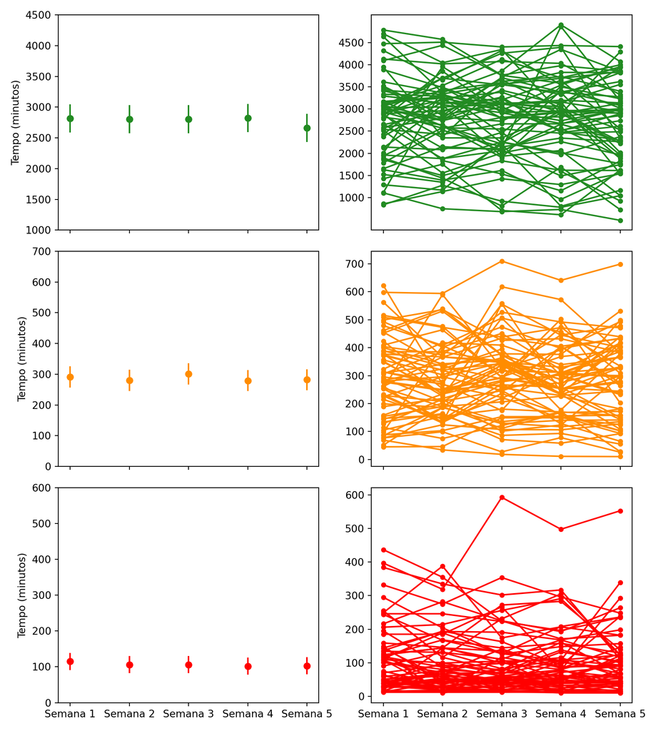

```python
plt.rcParams['axes.labelsize']=12
plt.rcParams['axes.titlesize']=12


plt.tight_layout()
fontP = FontProperties()
fontP.set_size('small')
#fig.autofmt_xdate(rotation=45)
fig.legend(loc='lower center', bbox_to_anchor=(0.5, -0.05), fancybox=True, shadow=True, ncol=3)
#plt.savefig('D:/Projeto_mestrado/Dissertacao/MastersDissertation/Modelos mistos/Gr?ficos/FLEEM/dados_FLEEM_ao_longo_do_tempo.png', bbox_inches='tight', dpi = 300)
#plt.savefig('D:/Projeto_mestrado/Dissertacao/MastersDissertation/Modelos mistos/Gr?ficos/FLEEM/dados_FLEEM_ao_longo_do_tempo_2.png', bbox_inches='tight', dpi = 300) # Para salvar uma vers?o com o eixo Y com valores que variam de acordo com o minimo e maximo das VDs
plt.show()
```

## IPAQ

```python
# Importar banco de dados
dados = pd.read_csv('D:/Projeto_mestrado/Dissertacao/MastersDissertation/Confiabilidade teste-reteste/Coeficiente de correlacao intraclasse/IPAQ/dados_ipaq_icc_wide.csv')

# Definidir valores do eixo X dos gráficos
semanas = ['Semana 1', 'Semana 2', 'Semana 3', 'Semana 4', 'Semana 5']


#Separando os dados por intensidade (IPAQ)
#Leve
dados_gerais_af_leve_ipaq = pd.DataFrame()
dados_gerais_af_leve_ipaq['Caminhada_IPAQ_10.1'] = pd.DataFrame(dados['Caminhada_IPAQ_10.1'])
dados_gerais_af_leve_ipaq['Caminhada_IPAQ_10.2'] = dados['Caminhada_IPAQ_10.2']
dados_gerais_af_leve_ipaq['Caminhada_IPAQ_10.3'] = dados['Caminhada_IPAQ_10.3']
dados_gerais_af_leve_ipaq['Caminhada_IPAQ_10.4'] = dados['Caminhada_IPAQ_10.4']
dados_gerais_af_leve_ipaq['Caminhada_IPAQ_10.5'] = dados['Caminhada_IPAQ_10.5']

#Moderada
dados_gerais_af_moderada_ipaq = pd.DataFrame()
dados_gerais_af_moderada_ipaq['Moderada_IPAQ_10.1'] = pd.DataFrame(dados['Moderada_IPAQ_10.1'])
dados_gerais_af_moderada_ipaq['Moderada_IPAQ_10.2'] = dados['Moderada_IPAQ_10.2']
dados_gerais_af_moderada_ipaq['Moderada_IPAQ_10.3'] = dados['Moderada_IPAQ_10.3']
dados_gerais_af_moderada_ipaq['Moderada_IPAQ_10.4'] = dados['Moderada_IPAQ_10.4']
dados_gerais_af_moderada_ipaq['Moderada_IPAQ_10.5'] = dados['Moderada_IPAQ_10.5']

#Vigorosa
dados_gerais_af_vigorosa_ipaq = pd.DataFrame()
dados_gerais_af_vigorosa_ipaq['Vigorosa_IPAQ_10.1'] = pd.DataFrame(dados['Vigorosa_IPAQ_10.1'])
dados_gerais_af_vigorosa_ipaq['Vigorosa_IPAQ_10.2'] = dados['Vigorosa_IPAQ_10.2']
dados_gerais_af_vigorosa_ipaq['Vigorosa_IPAQ_10.3'] = dados['Vigorosa_IPAQ_10.3']
dados_gerais_af_vigorosa_ipaq['Vigorosa_IPAQ_10.4'] = dados['Vigorosa_IPAQ_10.4']
dados_gerais_af_vigorosa_ipaq['Vigorosa_IPAQ_10.5'] = dados['Vigorosa_IPAQ_10.5']


#Separando os dados para cada indivíduo para cada intensidade

#Leve
# Inicialize uma lista vazia para armazenar as listas resultantes
listas_resultantes_leve = []

# Itere pelas linhas do DataFrame e crie uma lista para cada linha
for index, row in dados_gerais_af_leve_ipaq.iterrows():
    # Converte a linha para uma lista e a adiciona ? lista de resultados
    lista = row.tolist()
    listas_resultantes_leve.append(lista)


#Moderada
# Inicialize uma lista vazia para armazenar as listas resultantes
listas_resultantes_moderada = []

# Itere pelas linhas do DataFrame e crie uma lista para cada linha
for index, row in dados_gerais_af_moderada_ipaq.iterrows():
    # Converte a linha para uma lista e a adiciona ? lista de resultados
    lista = row.tolist()
    listas_resultantes_moderada.append(lista)

#Vigorosa
# Inicialize uma lista vazia para armazenar as listas resultantes
listas_resultantes_vigorosa = []

# Itere pelas linhas do DataFrame e crie uma lista para cada linha
for index, row in dados_gerais_af_vigorosa_ipaq.iterrows():
    # Converte a linha para uma lista e a adiciona ? lista de resultados
    lista = row.tolist()
    listas_resultantes_vigorosa.append(lista)



########################### Dados para a intensidade leve #########################
#Definindo valores do eixo Y para intensidade leve (com base nos outputs das análises)
leve_semana_1 = 433
leve_semana_2 = 361
leve_semana_3 = 346
leve_semana_4 = 353
leve_semana_5 = 272

#Calculando intervalos de confiança para intensidade leve (com base nos outputs das análises)
ic_leve_sem1 = 1.96*47.4
ic_leve_sem2 = 1.96*46.7
ic_leve_sem3 = 1.96*46.6
ic_leve_sem4 = 1.96*46.4
ic_leve_sem5 = 1.96*46.4

#Definindo o intervalo de confiança do gráfico para intensidade leve
yerr1_leve = ic_leve_sem1
yerr2_leve = ic_leve_sem2
yerr3_leve = ic_leve_sem3
yerr4_leve = ic_leve_sem4
yerr5_leve = ic_leve_sem5

########################### Dados para a intensidade moderada #########################
#Definindo valores do eixo Y para intensidade moderada
moderada_semana_1 = 394
moderada_semana_2 = 397
moderada_semana_3 = 391
moderada_semana_4 = 394
moderada_semana_5 = 395

#Calculando intervalos de confiança para intensidade moderada
ic_mod_sem1 = 1.96*27.8
ic_mod_sem2 = 1.96*28.6
ic_mod_sem3 = 1.96*28.0
ic_mod_sem4 = 1.96*28.1
ic_mod_sem5 = 1.96*28.1

#Definindo o intervalo de confiança do gráfico para intensidade moderada
yerr1_mod = ic_mod_sem1
yerr2_mod = ic_mod_sem2
yerr3_mod = ic_mod_sem3
yerr4_mod = ic_mod_sem4
yerr5_mod = ic_mod_sem5

########################### Dados para a intensidade vigorosa #########################
#Definindo valores do eixo Y para intensidade vigorosa
vigorosa_semana_1 = 147
vigorosa_semana_2 = 129
vigorosa_semana_3 = 157
vigorosa_semana_4 = 132
vigorosa_semana_5 = 130

#Calculando intervalos de confiança para intensidade vigorosa
ic_vig_sem1 = 1.96*22.0
ic_vig_sem2 = 1.96*21.5
ic_vig_sem3 = 1.96*21.6
ic_vig_sem4 = 1.96*21.5
ic_vig_sem5 = 1.96*21.6

#Definindo o intervalo de confiança do gráfico para intensidade vigorosa
yerr1_vig = ic_vig_sem1
yerr2_vig = ic_vig_sem2
yerr3_vig = ic_vig_sem3
yerr4_vig = ic_vig_sem4
yerr5_vig = ic_vig_sem5


#Construindo subplots com gráficos de média e IC e dados individuais ao longo das semanas IPAQ

#Gráficos com dados de atividade física leve
fig, ax = plt.subplots(nrows = 3, ncols = 2, figsize=(9,10), sharex=True)

# Construir gráficos com esperança e IC 95% para cada uma das semanas
ax[0,0].errorbar(['Semana 1'], leve_semana_1, yerr=yerr1_leve, fmt='-o', color = '#228B22')
ax[0,0].errorbar(['Semana 2'], leve_semana_2, yerr=yerr2_leve, fmt='-o', color = '#228B22')
ax[0,0].errorbar(['Semana 3'], leve_semana_3, yerr=yerr3_leve, fmt='-o', color = '#228B22')
ax[0,0].errorbar(['Semana 4'], leve_semana_4, yerr=yerr4_leve, fmt='-o', color = '#228B22')
ax[0,0].errorbar(['Semana 5'], leve_semana_5, yerr=yerr5_leve, fmt='-o', color = '#228B22')


ax[0,0].set_ylabel('Tempo (minutos)')
ax[0,0].set_yticks(range(0, 2000, 200))

# Construir gráficos com o comportamento de cada indivíduo ao longo das semanas
ax[0,1].plot(semanas, listas_resultantes_leve[0], color = '#228B22',linestyle='-', marker = 'o', markersize = 4, label = 'Caminhada')
ax[0,1].plot(semanas, listas_resultantes_leve[1], color = '#228B22', linestyle='-', marker = 'o', markersize = 4)
ax[0,1].plot(semanas, listas_resultantes_leve[2], color = '#228B22', linestyle='-', marker = 'o', markersize = 4)
ax[0,1].plot(semanas, listas_resultantes_leve[3], color = '#228B22', linestyle='-', marker = 'o', markersize = 4)
ax[0,1].plot(semanas, listas_resultantes_leve[4], color = '#228B22', linestyle='-', marker = 'o', markersize = 4)
ax[0,1].plot(semanas, listas_resultantes_leve[5], color = '#228B22', linestyle='-', marker = 'o', markersize = 4)
ax[0,1].plot(semanas, listas_resultantes_leve[6], color = '#228B22', linestyle='-', marker = 'o', markersize = 4)
ax[0,1].plot(semanas, listas_resultantes_leve[7], color = '#228B22', linestyle='-', marker = 'o', markersize = 4)
ax[0,1].plot(semanas, listas_resultantes_leve[8], color = '#228B22', linestyle='-', marker = 'o', markersize = 4)
ax[0,1].plot(semanas, listas_resultantes_leve[9], color = '#228B22', linestyle='-', marker = 'o', markersize = 4)
ax[0,1].plot(semanas, listas_resultantes_leve[10], color = '#228B22', linestyle='-', marker = 'o', markersize = 4)
ax[0,1].plot(semanas, listas_resultantes_leve[11], color = '#228B22', linestyle='-', marker = 'o', markersize = 4)
ax[0,1].plot(semanas, listas_resultantes_leve[12], color = '#228B22', linestyle='-', marker = 'o', markersize = 4)
ax[0,1].plot(semanas, listas_resultantes_leve[13], color = '#228B22', linestyle='-', marker = 'o', markersize = 4)
ax[0,1].plot(semanas, listas_resultantes_leve[14], color = '#228B22', linestyle='-', marker = 'o', markersize = 4)
ax[0,1].plot(semanas, listas_resultantes_leve[15], color = '#228B22', linestyle='-', marker = 'o', markersize = 4)
ax[0,1].plot(semanas, listas_resultantes_leve[16], color = '#228B22', linestyle='-', marker = 'o', markersize = 4)
ax[0,1].plot(semanas, listas_resultantes_leve[17], color = '#228B22', linestyle='-', marker = 'o', markersize = 4)
ax[0,1].plot(semanas, listas_resultantes_leve[18], color = '#228B22', linestyle='-', marker = 'o', markersize = 4)
ax[0,1].plot(semanas, listas_resultantes_leve[19], color = '#228B22', linestyle='-', marker = 'o', markersize = 4)
ax[0,1].plot(semanas, listas_resultantes_leve[20], color = '#228B22', linestyle='-', marker = 'o', markersize = 4)
ax[0,1].plot(semanas, listas_resultantes_leve[21], color = '#228B22', linestyle='-', marker = 'o', markersize = 4)
ax[0,1].plot(semanas, listas_resultantes_leve[22], color = '#228B22', linestyle='-', marker = 'o', markersize = 4)
ax[0,1].plot(semanas, listas_resultantes_leve[23], color = '#228B22', linestyle='-', marker = 'o', markersize = 4)
ax[0,1].plot(semanas, listas_resultantes_leve[24], color = '#228B22', linestyle='-', marker = 'o', markersize = 4)
ax[0,1].plot(semanas, listas_resultantes_leve[25], color = '#228B22', linestyle='-', marker = 'o', markersize = 4)
ax[0,1].plot(semanas, listas_resultantes_leve[26], color = '#228B22', linestyle='-', marker = 'o', markersize = 4)
ax[0,1].plot(semanas, listas_resultantes_leve[27], color = '#228B22', linestyle='-', marker = 'o', markersize = 4)
ax[0,1].plot(semanas, listas_resultantes_leve[28], color = '#228B22', linestyle='-', marker = 'o', markersize = 4)
ax[0,1].plot(semanas, listas_resultantes_leve[29], color = '#228B22', linestyle='-', marker = 'o', markersize = 4)
ax[0,1].plot(semanas, listas_resultantes_leve[30], color = '#228B22', linestyle='-', marker = 'o', markersize = 4)
ax[0,1].plot(semanas, listas_resultantes_leve[31], color = '#228B22', linestyle='-', marker = 'o', markersize = 4)
ax[0,1].plot(semanas, listas_resultantes_leve[32], color = '#228B22', linestyle='-', marker = 'o', markersize = 4)
ax[0,1].plot(semanas, listas_resultantes_leve[33], color = '#228B22', linestyle='-', marker = 'o', markersize = 4)
ax[0,1].plot(semanas, listas_resultantes_leve[34], color = '#228B22', linestyle='-', marker = 'o', markersize = 4)
ax[0,1].plot(semanas, listas_resultantes_leve[35], color = '#228B22', linestyle='-', marker = 'o', markersize = 4)
ax[0,1].plot(semanas, listas_resultantes_leve[36], color = '#228B22', linestyle='-', marker = 'o', markersize = 4)
ax[0,1].plot(semanas, listas_resultantes_leve[37], color = '#228B22', linestyle='-', marker = 'o', markersize = 4)
ax[0,1].plot(semanas, listas_resultantes_leve[38], color = '#228B22', linestyle='-', marker = 'o', markersize = 4)
ax[0,1].plot(semanas, listas_resultantes_leve[39], color = '#228B22', linestyle='-', marker = 'o', markersize = 4)
ax[0,1].plot(semanas, listas_resultantes_leve[40], color = '#228B22', linestyle='-', marker = 'o', markersize = 4)
ax[0,1].plot(semanas, listas_resultantes_leve[41], color = '#228B22', linestyle='-', marker = 'o', markersize = 4)
ax[0,1].plot(semanas, listas_resultantes_leve[42], color = '#228B22', linestyle='-', marker = 'o', markersize = 4)
ax[0,1].plot(semanas, listas_resultantes_leve[43], color = '#228B22', linestyle='-', marker = 'o', markersize = 4)
ax[0,1].plot(semanas, listas_resultantes_leve[44], color = '#228B22', linestyle='-', marker = 'o', markersize = 4)
ax[0,1].plot(semanas, listas_resultantes_leve[45], color = '#228B22', linestyle='-', marker = 'o', markersize = 4)
ax[0,1].plot(semanas, listas_resultantes_leve[46], color = '#228B22', linestyle='-', marker = 'o', markersize = 4)
ax[0,1].plot(semanas, listas_resultantes_leve[47], color = '#228B22', linestyle='-', marker = 'o', markersize = 4)
ax[0,1].plot(semanas, listas_resultantes_leve[48], color = '#228B22', linestyle='-', marker = 'o', markersize = 4)
ax[0,1].plot(semanas, listas_resultantes_leve[49], color = '#228B22', linestyle='-', marker = 'o', markersize = 4)
ax[0,1].plot(semanas, listas_resultantes_leve[50], color = '#228B22', linestyle='-', marker = 'o', markersize = 4)
ax[0,1].plot(semanas, listas_resultantes_leve[51], color = '#228B22', linestyle='-', marker = 'o', markersize = 4)
ax[0,1].plot(semanas, listas_resultantes_leve[52], color = '#228B22', linestyle='-', marker = 'o', markersize = 4)
ax[0,1].plot(semanas, listas_resultantes_leve[53], color = '#228B22', linestyle='-', marker = 'o', markersize = 4)
```

```python
ax[0,1].plot(semanas, listas_resultantes_leve[54], color = '#228B22', linestyle='-', marker = 'o', markersize = 4)
ax[0,1].plot(semanas, listas_resultantes_leve[55], color = '#228B22', linestyle='-', marker = 'o', markersize = 4)
ax[0,1].plot(semanas, listas_resultantes_leve[56], color = '#228B22', linestyle='-', marker = 'o', markersize = 4)
ax[0,1].plot(semanas, listas_resultantes_leve[57], color = '#228B22', linestyle='-', marker = 'o', markersize = 4)
ax[0,1].plot(semanas, listas_resultantes_leve[58], color = '#228B22', linestyle='-', marker = 'o', markersize = 4)
ax[0,1].plot(semanas, listas_resultantes_leve[59], color = '#228B22', linestyle='-', marker = 'o', markersize = 4)
ax[0,1].plot(semanas, listas_resultantes_leve[60], color = '#228B22', linestyle='-', marker = 'o', markersize = 4)
ax[0,1].plot(semanas, listas_resultantes_leve[61], color = '#228B22', linestyle='-', marker = 'o', markersize = 4)
ax[0,1].plot(semanas, listas_resultantes_leve[62], color = '#228B22', linestyle='-', marker = 'o', markersize = 4)

ax[0,1].set_yticks(range(0, 2000, 200))

#Gráficos com dados de atividade física moderada
# Construir gráficos com esperança e IC 95% para cada uma das semanas
ax[1,0].errorbar(['Semana 1'], moderada_semana_1, yerr=yerr1_mod, fmt='-o', color = '#FF8C00')
ax[1,0].errorbar(['Semana 2'], moderada_semana_2, yerr=yerr2_mod, fmt='-o', color = '#FF8C00')
ax[1,0].errorbar(['Semana 3'], moderada_semana_3, yerr=yerr3_mod, fmt='-o', color = '#FF8C00')
ax[1,0].errorbar(['Semana 4'], moderada_semana_4, yerr=yerr4_mod, fmt='-o', color = '#FF8C00')
ax[1,0].errorbar(['Semana 5'], moderada_semana_5, yerr=yerr5_mod, fmt='-o', color = '#FF8C00')

ax[1,0].set_ylabel('Tempo (minutos)')
ax[1,0].set_yticks(range(0, 2000, 200))

# Construir gráficos com o comportamento de cada indivíduo ao longo das semanas
ax[1,1].plot(semanas, listas_resultantes_moderada[0], color = '#FF8C00',linestyle='-', marker = 'o', markersize = 4, label = 'Moderada')
ax[1,1].plot(semanas, listas_resultantes_moderada[1], color = '#FF8C00', linestyle='-', marker = 'o', markersize = 4)
ax[1,1].plot(semanas, listas_resultantes_moderada[2], color = '#FF8C00', linestyle='-', marker = 'o', markersize = 4)
ax[1,1].plot(semanas, listas_resultantes_moderada[3], color = '#FF8C00', linestyle='-', marker = 'o', markersize = 4)
ax[1,1].plot(semanas, listas_resultantes_moderada[4], color = '#FF8C00', linestyle='-', marker = 'o', markersize = 4)
ax[1,1].plot(semanas, listas_resultantes_moderada[5], color = '#FF8C00', linestyle='-', marker = 'o', markersize = 4)
ax[1,1].plot(semanas, listas_resultantes_moderada[6], color = '#FF8C00', linestyle='-', marker = 'o', markersize = 4)
ax[1,1].plot(semanas, listas_resultantes_moderada[7], color = '#FF8C00', linestyle='-', marker = 'o', markersize = 4)
ax[1,1].plot(semanas, listas_resultantes_moderada[8], color = '#FF8C00', linestyle='-', marker = 'o', markersize = 4)
ax[1,1].plot(semanas, listas_resultantes_moderada[9], color = '#FF8C00', linestyle='-', marker = 'o', markersize = 4)
ax[1,1].plot(semanas, listas_resultantes_moderada[10], color = '#FF8C00', linestyle='-', marker = 'o', markersize = 4)
ax[1,1].plot(semanas, listas_resultantes_moderada[11], color = '#FF8C00', linestyle='-', marker = 'o', markersize = 4)
ax[1,1].plot(semanas, listas_resultantes_moderada[12], color = '#FF8C00', linestyle='-', marker = 'o', markersize = 4)
ax[1,1].plot(semanas, listas_resultantes_moderada[13], color = '#FF8C00', linestyle='-', marker = 'o', markersize = 4)
ax[1,1].plot(semanas, listas_resultantes_moderada[14], color = '#FF8C00', linestyle='-', marker = 'o', markersize = 4)
ax[1,1].plot(semanas, listas_resultantes_moderada[15], color = '#FF8C00', linestyle='-', marker = 'o', markersize = 4)
ax[1,1].plot(semanas, listas_resultantes_moderada[16], color = '#FF8C00', linestyle='-', marker = 'o', markersize = 4)
ax[1,1].plot(semanas, listas_resultantes_moderada[17], color = '#FF8C00', linestyle='-', marker = 'o', markersize = 4)
ax[1,1].plot(semanas, listas_resultantes_moderada[18], color = '#FF8C00', linestyle='-', marker = 'o', markersize = 4)
ax[1,1].plot(semanas, listas_resultantes_moderada[19], color = '#FF8C00', linestyle='-', marker = 'o', markersize = 4)
ax[1,1].plot(semanas, listas_resultantes_moderada[20], color = '#FF8C00', linestyle='-', marker = 'o', markersize = 4)
ax[1,1].plot(semanas, listas_resultantes_moderada[21], color = '#FF8C00', linestyle='-', marker = 'o', markersize = 4)
ax[1,1].plot(semanas, listas_resultantes_moderada[22], color = '#FF8C00', linestyle='-', marker = 'o', markersize = 4)
ax[1,1].plot(semanas, listas_resultantes_moderada[23], color = '#FF8C00', linestyle='-', marker = 'o', markersize = 4)
ax[1,1].plot(semanas, listas_resultantes_moderada[24], color = '#FF8C00', linestyle='-', marker = 'o', markersize = 4)
ax[1,1].plot(semanas, listas_resultantes_moderada[25], color = '#FF8C00', linestyle='-', marker = 'o', markersize = 4)
ax[1,1].plot(semanas, listas_resultantes_moderada[26], color = '#FF8C00', linestyle='-', marker = 'o', markersize = 4)
ax[1,1].plot(semanas, listas_resultantes_moderada[27], color = '#FF8C00', linestyle='-', marker = 'o', markersize = 4)
ax[1,1].plot(semanas, listas_resultantes_moderada[28], color = '#FF8C00', linestyle='-', marker = 'o', markersize = 4)
ax[1,1].plot(semanas, listas_resultantes_moderada[29], color = '#FF8C00', linestyle='-', marker = 'o', markersize = 4)
ax[1,1].plot(semanas, listas_resultantes_moderada[30], color = '#FF8C00', linestyle='-', marker = 'o', markersize = 4)
ax[1,1].plot(semanas, listas_resultantes_moderada[31], color = '#FF8C00', linestyle='-', marker = 'o', markersize = 4)
ax[1,1].plot(semanas, listas_resultantes_moderada[32], color = '#FF8C00', linestyle='-', marker = 'o', markersize = 4)
ax[1,1].plot(semanas, listas_resultantes_moderada[33], color = '#FF8C00', linestyle='-', marker = 'o', markersize = 4)
ax[1,1].plot(semanas, listas_resultantes_moderada[34], color = '#FF8C00', linestyle='-', marker = 'o', markersize = 4)
ax[1,1].plot(semanas, listas_resultantes_moderada[35], color = '#FF8C00', linestyle='-', marker = 'o', markersize = 4)
ax[1,1].plot(semanas, listas_resultantes_moderada[36], color = '#FF8C00', linestyle='-', marker = 'o', markersize = 4)
ax[1,1].plot(semanas, listas_resultantes_moderada[37], color = '#FF8C00', linestyle='-', marker = 'o', markersize = 4)
ax[1,1].plot(semanas, listas_resultantes_moderada[38], color = '#FF8C00', linestyle='-', marker = 'o', markersize = 4)
ax[1,1].plot(semanas, listas_resultantes_moderada[39], color = '#FF8C00', linestyle='-', marker = 'o', markersize = 4)
ax[1,1].plot(semanas, listas_resultantes_moderada[40], color = '#FF8C00', linestyle='-', marker = 'o', markersize = 4)
ax[1,1].plot(semanas, listas_resultantes_moderada[41], color = '#FF8C00', linestyle='-', marker = 'o', markersize = 4)
ax[1,1].plot(semanas, listas_resultantes_moderada[42], color = '#FF8C00', linestyle='-', marker = 'o', markersize = 4)
ax[1,1].plot(semanas, listas_resultantes_moderada[43], color = '#FF8C00', linestyle='-', marker = 'o', markersize = 4)
ax[1,1].plot(semanas, listas_resultantes_moderada[44], color = '#FF8C00', linestyle='-', marker = 'o', markersize = 4)
ax[1,1].plot(semanas, listas_resultantes_moderada[45], color = '#FF8C00', linestyle='-', marker = 'o', markersize = 4)
ax[1,1].plot(semanas, listas_resultantes_moderada[46], color = '#FF8C00', linestyle='-', marker = 'o', markersize = 4)
ax[1,1].plot(semanas, listas_resultantes_moderada[47], color = '#FF8C00', linestyle='-', marker = 'o', markersize = 4)
ax[1,1].plot(semanas, listas_resultantes_moderada[48], color = '#FF8C00', linestyle='-', marker = 'o', markersize = 4)
ax[1,1].plot(semanas, listas_resultantes_moderada[49], color = '#FF8C00', linestyle='-', marker = 'o', markersize = 4)
ax[1,1].plot(semanas, listas_resultantes_moderada[50], color = '#FF8C00', linestyle='-', marker = 'o', markersize = 4)
ax[1,1].plot(semanas, listas_resultantes_moderada[51], color = '#FF8C00', linestyle='-', marker = 'o', markersize = 4)
ax[1,1].plot(semanas, listas_resultantes_moderada[52], color = '#FF8C00', linestyle='-', marker = 'o', markersize = 4)
ax[1,1].plot(semanas, listas_resultantes_moderada[53], color = '#FF8C00', linestyle='-', marker = 'o', markersize = 4)
ax[1,1].plot(semanas, listas_resultantes_moderada[54], color = '#FF8C00', linestyle='-', marker = 'o', markersize = 4)
ax[1,1].plot(semanas, listas_resultantes_moderada[55], color = '#FF8C00', linestyle='-', marker = 'o', markersize = 4)
ax[1,1].plot(semanas, listas_resultantes_moderada[56], color = '#FF8C00', linestyle='-', marker = 'o', markersize = 4)
ax[1,1].plot(semanas, listas_resultantes_moderada[57], color = '#FF8C00', linestyle='-', marker = 'o', markersize = 4)
ax[1,1].plot(semanas, listas_resultantes_moderada[58], color = '#FF8C00', linestyle='-', marker = 'o', markersize = 4)
ax[1,1].plot(semanas, listas_resultantes_moderada[59], color = '#FF8C00', linestyle='-', marker = 'o', markersize = 4)
ax[1,1].plot(semanas, listas_resultantes_moderada[60], color = '#FF8C00', linestyle='-', marker = 'o', markersize = 4)
ax[1,1].plot(semanas, listas_resultantes_moderada[61], color = '#FF8C00', linestyle='-', marker = 'o', markersize = 4)
ax[1,1].plot(semanas, listas_resultantes_moderada[62], color = '#FF8C00', linestyle='-', marker = 'o', markersize = 4)
```

```python
ax[1,1].set_yticks(range(0, 2000, 200))

#Gráficos com dados de atividade física vigorosa
# Construir gráficos com esperança e IC 95% para cada uma das semanas
ax[2,0].errorbar(['Semana 1'], vigorosa_semana_1, yerr=yerr1_vig, fmt='-o', color = '#FF0000')
ax[2,0].errorbar(['Semana 2'], vigorosa_semana_2, yerr=yerr2_vig, fmt='-o', color = '#FF0000')
ax[2,0].errorbar(['Semana 3'], vigorosa_semana_3, yerr=yerr3_vig, fmt='-o', color = '#FF0000')
ax[2,0].errorbar(['Semana 4'], vigorosa_semana_4, yerr=yerr4_vig, fmt='-o', color = '#FF0000')
ax[2,0].errorbar(['Semana 5'], vigorosa_semana_5, yerr=yerr5_vig, fmt='-o', color = '#FF0000')

ax[2,0].set_ylabel('Tempo (minutos)')
ax[2,0].set_yticks(range(0, 1000, 100))

# Construir gráficos com o comportamento de cada indivíduo ao longo das semanas
ax[2,1].plot(semanas, listas_resultantes_vigorosa[0], color = '#FF0000',linestyle='-', marker = 'o', markersize = 4, label = 'Vigorosa')
ax[2,1].plot(semanas, listas_resultantes_vigorosa[1], color = '#FF0000', linestyle='-', marker = 'o', markersize = 4)
ax[2,1].plot(semanas, listas_resultantes_vigorosa[2], color = '#FF0000', linestyle='-', marker = 'o', markersize = 4)
ax[2,1].plot(semanas, listas_resultantes_vigorosa[3], color = '#FF0000', linestyle='-', marker = 'o', markersize = 4)
ax[2,1].plot(semanas, listas_resultantes_vigorosa[4], color = '#FF0000', linestyle='-', marker = 'o', markersize = 4)
ax[2,1].plot(semanas, listas_resultantes_vigorosa[5], color = '#FF0000', linestyle='-', marker = 'o', markersize = 4)
ax[2,1].plot(semanas, listas_resultantes_vigorosa[6], color = '#FF0000', linestyle='-', marker = 'o', markersize = 4)
ax[2,1].plot(semanas, listas_resultantes_vigorosa[7], color = '#FF0000', linestyle='-', marker = 'o', markersize = 4)
ax[2,1].plot(semanas, listas_resultantes_vigorosa[8], color = '#FF0000', linestyle='-', marker = 'o', markersize = 4)
ax[2,1].plot(semanas, listas_resultantes_vigorosa[9], color = '#FF0000', linestyle='-', marker = 'o', markersize = 4)
ax[2,1].plot(semanas, listas_resultantes_vigorosa[10], color = '#FF0000', linestyle='-', marker = 'o', markersize = 4)
ax[2,1].plot(semanas, listas_resultantes_vigorosa[11], color = '#FF0000', linestyle='-', marker = 'o', markersize = 4)
ax[2,1].plot(semanas, listas_resultantes_vigorosa[12], color = '#FF0000', linestyle='-', marker = 'o', markersize = 4)
ax[2,1].plot(semanas, listas_resultantes_vigorosa[13], color = '#FF0000', linestyle='-', marker = 'o', markersize = 4)
ax[2,1].plot(semanas, listas_resultantes_vigorosa[14], color = '#FF0000', linestyle='-', marker = 'o', markersize = 4)
ax[2,1].plot(semanas, listas_resultantes_vigorosa[15], color = '#FF0000', linestyle='-', marker = 'o', markersize = 4)
ax[2,1].plot(semanas, listas_resultantes_vigorosa[16], color = '#FF0000', linestyle='-', marker = 'o', markersize = 4)
ax[2,1].plot(semanas, listas_resultantes_vigorosa[17], color = '#FF0000', linestyle='-', marker = 'o', markersize = 4)
ax[2,1].plot(semanas, listas_resultantes_vigorosa[18], color = '#FF0000', linestyle='-', marker = 'o', markersize = 4)
ax[2,1].plot(semanas, listas_resultantes_vigorosa[19], color = '#FF0000', linestyle='-', marker = 'o', markersize = 4)
ax[2,1].plot(semanas, listas_resultantes_vigorosa[20], color = '#FF0000', linestyle='-', marker = 'o', markersize = 4)
ax[2,1].plot(semanas, listas_resultantes_vigorosa[21], color = '#FF0000', linestyle='-', marker = 'o', markersize = 4)
ax[2,1].plot(semanas, listas_resultantes_vigorosa[22], color = '#FF0000', linestyle='-', marker = 'o', markersize = 4)
ax[2,1].plot(semanas, listas_resultantes_vigorosa[23], color = '#FF0000', linestyle='-', marker = 'o', markersize = 4)
ax[2,1].plot(semanas, listas_resultantes_vigorosa[24], color = '#FF0000', linestyle='-', marker = 'o', markersize = 4)
ax[2,1].plot(semanas, listas_resultantes_vigorosa[25], color = '#FF0000', linestyle='-', marker = 'o', markersize = 4)
ax[2,1].plot(semanas, listas_resultantes_vigorosa[26], color = '#FF0000', linestyle='-', marker = 'o', markersize = 4)
ax[2,1].plot(semanas, listas_resultantes_vigorosa[27], color = '#FF0000', linestyle='-', marker = 'o', markersize = 4)
ax[2,1].plot(semanas, listas_resultantes_vigorosa[28], color = '#FF0000', linestyle='-', marker = 'o', markersize = 4)
ax[2,1].plot(semanas, listas_resultantes_vigorosa[29], color = '#FF0000', linestyle='-', marker = 'o', markersize = 4)
ax[2,1].plot(semanas, listas_resultantes_vigorosa[30], color = '#FF0000', linestyle='-', marker = 'o', markersize = 4)
ax[2,1].plot(semanas, listas_resultantes_vigorosa[31], color = '#FF0000', linestyle='-', marker = 'o', markersize = 4)
ax[2,1].plot(semanas, listas_resultantes_vigorosa[32], color = '#FF0000', linestyle='-', marker = 'o', markersize = 4)
ax[2,1].plot(semanas, listas_resultantes_vigorosa[33], color = '#FF0000', linestyle='-', marker = 'o', markersize = 4)
ax[2,1].plot(semanas, listas_resultantes_vigorosa[34], color = '#FF0000', linestyle='-', marker = 'o', markersize = 4)
ax[2,1].plot(semanas, listas_resultantes_vigorosa[35], color = '#FF0000', linestyle='-', marker = 'o', markersize = 4)
ax[2,1].plot(semanas, listas_resultantes_vigorosa[36], color = '#FF0000', linestyle='-', marker = 'o', markersize = 4)
ax[2,1].plot(semanas, listas_resultantes_vigorosa[37], color = '#FF0000', linestyle='-', marker = 'o', markersize = 4)
ax[2,1].plot(semanas, listas_resultantes_vigorosa[38], color = '#FF0000', linestyle='-', marker = 'o', markersize = 4)
ax[2,1].plot(semanas, listas_resultantes_vigorosa[39], color = '#FF0000', linestyle='-', marker = 'o', markersize = 4)
ax[2,1].plot(semanas, listas_resultantes_vigorosa[40], color = '#FF0000', linestyle='-', marker = 'o', markersize = 4)
ax[2,1].plot(semanas, listas_resultantes_vigorosa[41], color = '#FF0000', linestyle='-', marker = 'o', markersize = 4)
ax[2,1].plot(semanas, listas_resultantes_vigorosa[42], color = '#FF0000', linestyle='-', marker = 'o', markersize = 4)
ax[2,1].plot(semanas, listas_resultantes_vigorosa[43], color = '#FF0000', linestyle='-', marker = 'o', markersize = 4)
ax[2,1].plot(semanas, listas_resultantes_vigorosa[44], color = '#FF0000', linestyle='-', marker = 'o', markersize = 4)
ax[2,1].plot(semanas, listas_resultantes_vigorosa[45], color = '#FF0000', linestyle='-', marker = 'o', markersize = 4)
ax[2,1].plot(semanas, listas_resultantes_vigorosa[46], color = '#FF0000', linestyle='-', marker = 'o', markersize = 4)
ax[2,1].plot(semanas, listas_resultantes_vigorosa[47], color = '#FF0000', linestyle='-', marker = 'o', markersize = 4)
ax[2,1].plot(semanas, listas_resultantes_vigorosa[48], color = '#FF0000', linestyle='-', marker = 'o', markersize = 4)
ax[2,1].plot(semanas, listas_resultantes_vigorosa[49], color = '#FF0000', linestyle='-', marker = 'o', markersize = 4)
ax[2,1].plot(semanas, listas_resultantes_vigorosa[50], color = '#FF0000', linestyle='-', marker = 'o', markersize = 4)
ax[2,1].plot(semanas, listas_resultantes_vigorosa[51], color = '#FF0000', linestyle='-', marker = 'o', markersize = 4)
ax[2,1].plot(semanas, listas_resultantes_vigorosa[52], color = '#FF0000', linestyle='-', marker = 'o', markersize = 4)
ax[2,1].plot(semanas, listas_resultantes_vigorosa[53], color = '#FF0000', linestyle='-', marker = 'o', markersize = 4)
ax[2,1].plot(semanas, listas_resultantes_vigorosa[54], color = '#FF0000', linestyle='-', marker = 'o', markersize = 4)
ax[2,1].plot(semanas, listas_resultantes_vigorosa[55], color = '#FF0000', linestyle='-', marker = 'o', markersize = 4)
ax[2,1].plot(semanas, listas_resultantes_vigorosa[56], color = '#FF0000', linestyle='-', marker = 'o', markersize = 4)
ax[2,1].plot(semanas, listas_resultantes_vigorosa[57], color = '#FF0000', linestyle='-', marker = 'o', markersize = 4)
ax[2,1].plot(semanas, listas_resultantes_vigorosa[58], color = '#FF0000', linestyle='-', marker = 'o', markersize = 4)
ax[2,1].plot(semanas, listas_resultantes_vigorosa[59], color = '#FF0000', linestyle='-', marker = 'o', markersize = 4)
ax[2,1].plot(semanas, listas_resultantes_vigorosa[60], color = '#FF0000', linestyle='-', marker = 'o', markersize = 4)
ax[2,1].plot(semanas, listas_resultantes_vigorosa[61], color = '#FF0000', linestyle='-', marker = 'o', markersize = 4)
ax[2,1].plot(semanas, listas_resultantes_vigorosa[62], color = '#FF0000', linestyle='-', marker = 'o', markersize = 4)
```

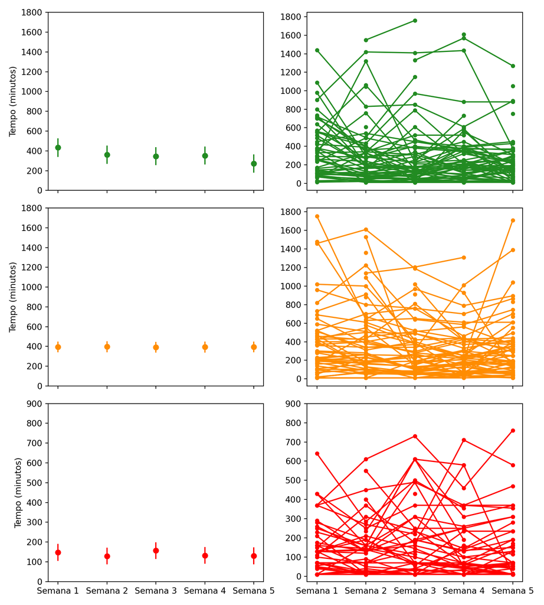

```python
ax[2,1].set_yticks(range(0, 1000, 100))

plt.rcParams['axes.labelsize']=12
plt.rcParams['axes.titlesize']=12


plt.tight_layout()
fontP = FontProperties()
fontP.set_size('small')
fig.legend(loc='lower center', bbox_to_anchor=(0.5, -0.05), fancybox=True, shadow=True, ncol=3)
#plt.savefig('D:/Projeto_mestrado/Dissertacao/MastersDissertation/Modelos mistos/Gr?ficos/IPAQ/Dados_IPAQ_ao_longo_do_tempo_1.png', bbox_inches='tight', dpi = 300)
#plt.savefig('D:/Projeto_mestrado/Dissertacao/MastersDissertation/Modelos mistos/Gr?ficos/IPAQ/Dados_IPAQ_ao_longo_do_tempo_2.png', bbox_inches='tight', dpi = 300)
plt.show()
```